# Objectives and Project Approach

In order to evaluate the business opportunity for Kaluza, we state the questions that must be answered in the process.

- How much energy is currently curtailed annually across the Orkney Isles? Answer: **Section 1.3.2**
- How much can this be reduced by different levels of DR penetration? Answer: **Section 3.1**
- How many local households would need to be on our DR scheme in order to supply this level of DR? Answer: **Section 3.2**

```python
import numpy as np
import pandas as pd
import matplotlib.pyplot as plt

from sklearn.metrics import mean_squared_error, r2_score
from sklearn.linear_model import LinearRegression
import math
from datetime import timedelta
import warnings
import calendar
import seaborn as sns
import statsmodels.formula.api as smf
warnings.filterwarnings("ignore")
```

# 1. Supply

This section of the report analyzes the energy supply status. The study focuses on analyzing how much energy the wind turbines in the Orkney Islands currently generate, and how much of this energy is curtailed. The data analysis makes use primarily of the `turbine_telemetry` dataset.

```python
turbine_telemetry = pd.read_csv("turbine_telemetry.csv" , parse_dates=['Timestamp'])
```

Description of **turbine_telemetry dataset**:

- Timestamp: time stamp in 1 minute increment from 2015-05-28 00:00:23 to 2018-01-11 06:14:32
- Power_kw: power in kw at the timestamp
- Setpoint_kw: the amount of kw that a control system is aiming to reach
- Wind_ms: wind speed measurement

All of the above for a single wind turbine in Orkney, precisely in Rousay.

## 1.1 Exploratory data analysis and data pre-processing

In this section, we will handle the raw data with the following steps:

- Missing value analysis
- Time series analysis
- Power and setpoint relationship analysis
- Power and wind relationship analysis

These steps aim to exclude data inconsistencies, missing values or potentially noisy data.

#### i. Missing value Analysis

**Removing Missing values 2015**: Exploratory data analysis shows that a substantial portion of the second half of 2015 lacks telemetry records. Since data collection only begins in late May 2015, we restrict our analysis to the period from January 1, 2016, to January 1, 2018, aligned with the available residential demand data. This adjustment does not compromise result quality due to the ample volume of data in the selected window. Attempting to interpolate the extensive gaps in 2015, 187 out of 218 days between May 28 and December 31—would likely introduce distortion and bias. The distribution of available days is detailed in **Appendix A (Missing value Analysis)**.

```python
# Removes missing values from the data
turbine_telemetry_ = turbine_telemetry.set_index('Timestamp')
turbine_telemetry_ = turbine_telemetry_.loc['2016-01-01':'2018-01-01']
turbine_telemetry_ = turbine_telemetry_.dropna()
```

```python
# Removes missing values from the data
turbine_telemetry_cur = turbine_telemetry.set_index('Timestamp')
turbine_telemetry_cur = turbine_telemetry_cur.loc['2016-01-01':'2018-01-01']
turbine_telemetry_cur = turbine_telemetry_cur.dropna()
```

```python
turbine_telemetry_.head()
```

| Timestamp | Power_kw | Setpoint_kw | Wind_ms |
| --- | --- | --- | --- |
| 2016-01-01 00:00:34 | 904.0 | 900.0 | 17.0 |
| 2016-01-01 00:01:34 | 899.0 | 900.0 | 15.1 |
| 2016-01-01 00:02:34 | 911.0 | 900.0 | 18.1 |
| 2016-01-01 00:03:34 | 900.0 | 900.0 | 23.1 |
| 2016-01-01 00:04:34 | 903.0 | 900.0 | 19.4 |

#### ii. Time-Series Analysis

Wind power generation fluctuates over the course of the year, indicating strong seasonal patterns in the data. Time series analysis is useful for visualizing the data range, identifying seasonal trends in turbine output, and gaining insights into key characteristics. This step is particularly important because the wind generation and energy demand data are recorded at different time intervals, making it crucial to understand and account for these discrepancies in subsequent analysis.

**Timestamp frequency**: Initial inspection of the timestamps indicates that the data is generally recorded at consistent one-minute intervals, with a few irregularities. These anomalies are addressed during aggregation, where the data is resampled into 30-minute intervals to align with the frequency of the demand dataset.

```python
telemetry = turbine_telemetry.set_index('Timestamp')
timing = pd.Series(telemetry.index).diff()
one_min = pd.Timedelta(minutes=1) # the data appears to be evenly spaced in one-minute intervals

print(round((timing == one_min).sum() / len(timing),2)*100,'% data is one-minute intervals')
```

```
98.0 % data is one-minute intervals
```

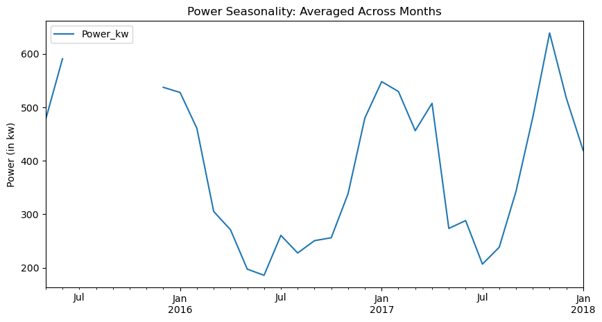

```python
# Power seasonality analysis (monthly averages) - DATA
telemetry_avg = telemetry.resample('ME').mean()

# Power seasonality analysis (monthly averages) - VISUALISATION
telemetry_avg.plot(y='Power_kw', use_index=True, figsize = (10,5))

plt.xlabel("")
plt.ylabel("Power (in kw)")
plt.title('Power Seasonality: Averaged Across Months')
plt.show()
```

#### iii. Power and setpoint analysis

The setpoint of wind turbines acts as a control parameter for curtailment, determining the cap on power output. It can be adjusted anywhere between 0 and the turbine’s maximum capacity, which is 900 KW in this case. When the setpoint is set below 900 KW, it results in a loss of potential energy generation.

As part of quality control, we examine the number of instances where the recorded power output exceeds the setpoint. Such occurrences may indicate measurement errors or data inconsistencies that warrant further investigation.

```python
# Studies cases when the power (kw) record exceeds the setpoint record (kw)
is_power_bigger = turbine_telemetry['Power_kw'] > turbine_telemetry['Setpoint_kw']
telemetry_filter = turbine_telemetry[is_power_bigger]
print('Instances where power (kw) > setpoint (kw):',len(telemetry_filter))
```

```
Instances where power (kw) > setpoint (kw): 139101
```

Additionally, for these specific instances, we investigate: by how many kilowatts does the recorded power output exceed the setpoint? This helps quantify the extent of the discrepancy and assess the severity of potential measurement errors.

```python
# On average how much power (kw) exceeds the set point (kw) - for the relevant cases
telemetry_filter.loc[:, 'Extra'] = telemetry_filter['Power_kw'] - telemetry_filter['Setpoint_kw']
print('On average the power (kw) surpasses the setpoint by',round(telemetry_filter['Extra'].mean(),2),'kw')
```

```
On average the power (kw) surpasses the setpoint by 17.67 kw
```

Based on these findings, we perform data preprocessing to prepare the data for modeling in the next section.

**Power and setpoint filtering:** Exploratory data analysis identifies cases where the recorded power output exceeds the setpoint at a given timestamp. For such instances, if the power surpasses the setpoint by more than 1%, the data point is removed, as this likely reflects a significant measurement error. However, if the excess is less than or equal to 1%, it is treated as a minor discrepancy. In these cases, the data point is retained but the power value is capped at the setpoint to maintain consistency.

```python
# Step 1: Create a mask for large overshoots (>1%)
mask_overshoot_1 = turbine_telemetry_["Power_kw"] > (turbine_telemetry_["Setpoint_kw"] * 1.01)

# Step 2: Drop those rows directly from turbine_telemetry_
turbine_telemetry_ = turbine_telemetry_[~mask_overshoot_1].copy()

# Step 3: Print summary
print("Overshoot Summary:")
print(f"  - Dropped rows with > 1% overshoot: {mask_overshoot_1.sum()}")
print(f"  - Remaining rows: {len(turbine_telemetry_)}")
```

```
Overshoot Summary:
  - Dropped rows with > 1% overshoot: 57411
  - Remaining rows: 951435
```

#### iv. Power and wind relationship analysis

Wind speed plays a critical role in determining the energy output of a wind turbine. As wind speed increases, the turbine blades spin faster, up to the turbine’s design limits, resulting in greater mechanical energy, which is then converted into electrical power by the generator. Importantly, the power output of a wind turbine generally increases with the cube of the wind speed, making small increases in wind velocity highly impactful. This cubic relationship between wind speed (m/s) and power output (kW) is illustrated in the figure below.

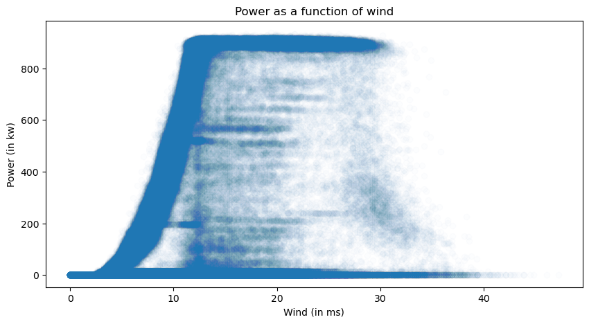

```python
# Power as a function of wind - VISUALIZATION
plt.figure(figsize=(10, 5))
plt.scatter(turbine_telemetry["Wind_ms"],turbine_telemetry["Power_kw"], alpha =0.01)
plt.xlabel("Wind (in ms)")
plt.ylabel("Power (in kw)")
plt.title("Power as a function of wind")
plt.show()
```

In order to estimate the maximum potentail generated power based on wind speed, we need construct a forecasting model on this data set. However, before doing so, we require the following pre-processing steps.

**1. Filter Curtailed Cases (Setpoint $\ne$ 900)**

To ensure an accurate representation of the turbine's true generation potential, we filter out curtailed cases, i.e., all entries where the setpoint is not equal to 900 kW. This helps eliminate distortions caused by imposed output limits, allowing us to analyze the natural relationship between wind speed and power generation.

```python
# Filters data for uncurtailed periods
mask2 = turbine_telemetry_['Setpoint_kw'] == 900
turbine_telemetry_ = turbine_telemetry_[mask2]
```

**2. Minimum Wind Speed**

We exclude data points where the wind speed exceeds 3.0 m/s but the recorded power output is 0 kW. Such cases are likely to indicate measurement errors or operational issues unrelated to wind availability, and could otherwise misrepresent the turbine's performance under typical wind conditions.

```python
# Minimum speed filtering
mask3 = (turbine_telemetry_['Wind_ms'] > 3.0) & (turbine_telemetry_['Power_kw'] == 0)
turbine_telemetry_ = turbine_telemetry_[-mask3]   #Removing all data with 0 power > 3 m/s
```

**3. Maximum Wind Speed**

We remove entries where wind speed exceeds 20.0 m/s but power output is less than or equal to 800 kW. Under normal turbine operation, high wind speeds near or above 20 m/s should result in power output close to the turbine’s rated capacity (900 kW). Such discrepancies may indicate curtailment, sensor faults, or system inefficiencies, and are therefore excluded to preserve data quality.

```python
#Maximum speed filtering
mask4 = (turbine_telemetry_['Wind_ms'] > 20.0) & (turbine_telemetry_['Power_kw'] < 800)
turbine_telemetry_ = turbine_telemetry_[-mask4]
```

**Power and Wind Relationship after Data Preprocessing**

The plot shows the relationship between wind and power. The maximum power is bounded at 900 KW, and a positive accelerating relationship between wind and power can be clearly observed.

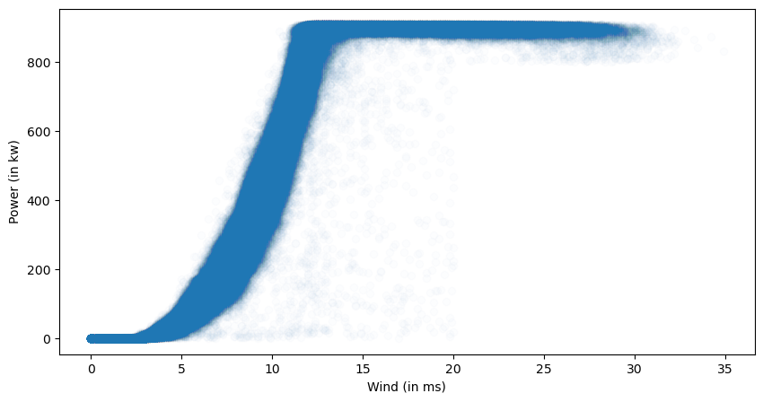

```python
# Power as a function of wind speed
plt.figure(figsize=(10, 5))
plt.scatter(turbine_telemetry_["Wind_ms"],turbine_telemetry_["Power_kw"], alpha =0.01)
plt.xlabel("Wind (in ms)")
plt.ylabel("Power (in kw)")
plt.show()
```

## 1.2 Forecasting Model

We use a series of forecasting models to estimate the potential energy output based solely on wind speeds, independent of curtailment effects. By comparing these projected values with the actual generation recorded in the `turbine_telemetry` dataset, we can quantify the unrealised energy due to curtailment.

In total, four forecasting models are developed:

**1. Mean Model**: Power output is estimated by averaging observed values for each unique wind speed, using the full range of wind speed data at the minimum granularity present in the dataset.

- **Median Model**: A variation of the Mean Model, this approach uses the median power output for each unique wind speed value instead of the mean to reduce sensitivity to outliers.

**2. Binning Model:** Wind speeds are grouped into bins of 0.5 m/s, covering the range from 0 to 31 m/s. The average power output is calculated for each bin, capturing broader patterns while smoothing minor fluctuations.

**3. Linear Model:** A simple regression model that assumes a linear relationship between wind speed and power output: $$Power\_kw=−163.24+60.79 \times Wind\_ms$$

These models enable estimation of the theoretical (unconstrained) generation potential, allowing us to assess the extent of energy lost due to curtailment.

Accordingly, **we select the mean model to estimate the maximum potential power generation**, as it provides a detailed and data-driven mapping of wind speed to power output. The methodology and implementation of this model are outlined below. For a comprehensive overview of alternative models (2) through (4), please refer to **Appendix A (Models)**.

#### Mean Model

The mean model estimates power output by calculating the average power generated at each unique wind speed value (`wind_ms`), effectively using wind speed as a data segmentation tool. This method offers a detailed and precise estimation of power across the full range of observed wind speeds. When applying the model to wind speed values not explicitly present in the training data, we impute the corresponding power output by averaging the power values of the two nearest wind speed points.

```python
# Mean model calibration
predict_power_dict={}
for i in np.unique(turbine_telemetry_["Wind_ms"]):
    predict_power_dict[i]= np.mean(turbine_telemetry_[turbine_telemetry_["Wind_ms"]==i]["Power_kw"])
predict_power_list=[]
for w in turbine_telemetry_["Wind_ms"]:
    #print(w)
    p_tmp= predict_power_dict[w]
    predict_power_list.append(p_tmp)
turbine_telemetry_["Mean_Predicted_Power_kw"]= predict_power_list
```

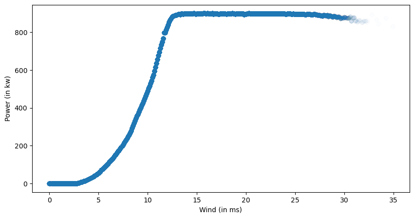

```python
# Mean model - VISUALIZATION
plt.figure(figsize=(10, 5))
plt.scatter(turbine_telemetry_["Wind_ms"],turbine_telemetry_["Mean_Predicted_Power_kw"], alpha =0.01)
plt.xlabel("Wind (in ms)")
plt.ylabel("Power (in kw)")
plt.show()
```

```python
# Mean model RMSE calculation
MSE_avg = mean_squared_error(turbine_telemetry_["Power_kw"], turbine_telemetry_["Mean_Predicted_Power_kw"])
RMSE_avg = math.sqrt(MSE_avg)
print("The mean model has a RMSE of", round(RMSE_avg,2))
```

```
The mean model has a RMSE of 42.04
```

## 1.3 Curtailment Estimation

Building on the forecasting model described in Section 1.2, we estimate the maximum potential power generation corresponding to observed wind speeds. Using this benchmark, we then quantify the amount of energy curtailed each year in the Orkney Islands.

This section details the key assumptions made in estimating curtailment and presents the methodology used to calculate total curtailed energy for the years 2016 and 2017.

### 1.3.1 Assumptions

**1. Curtailed Power Formulation:** To estimate curtailed power on a per-minute basis, we compute the difference between the potential maximum power generation (as predicted by the wind speed-based model) and the actual power output of the turbine. The maximum potential reflects the turbine's capability given prevailing wind conditions, while the actual output is limited by the setpoint, a constraint introduced by curtailment measures. Therefore, the setpoint effectively governs the magnitude of curtailed power.

**1.1. Curtailed Energy Formulation:** To align turbine supply data with household demand data, we aggregate curtailed power into 30-minute intervals. Curtailment in terms of energy (kWh) is calculated as the integral of curtailed power over each 30-minute period, providing a directly comparable measure to residential energy consumption.

**2. Total Number of Wind Turbines:** There are approximately 500 wind turbines operating across various wind farms in the Orkney Islands **[Orkney Renewable Energy Forum, 2022](https://www.oref.co.uk/orkneys-energy-1/wind/)**.

- **North Isles:** Eday, Sanday, Shapinsay, Stronsay, Rousay, Westray
- **South Isles:** Flotta, Burray, Hoy

[figure not shown]

**4. Geographical Dispersion:** Building on Assumption 3, we acknowledge that power, and consequently energy, generation will vary across locations due to differing wind conditions. To account for this, we estimate geographical dispersion in wind generation using historical annual average wind speeds (measured in m/s) for each site. These values provide a basis for adjusting curtailment estimates according to local wind profiles. Data is sourced from **[Weather and Climate, 2018](https://weatherandclimate.com/united-kingdom/orkney-islands/burray-village/January-2018)** and **[MyWeather2](https://www.myweather2.com/City-Town/United-Kingdom/Orkney-Islands/Flotta/climate-profile.aspx?month=1)**

### 1.3.2 Estimation

To estimate the curtailed energy, we follow a structured approach:

1. Compute the **potential maximum energy per minute** – this represents the theoretical energy generation in the absence of curtailment, based on wind speed.
2. Determine **curtailed energy per minute** – calculated as the difference between potential and actual energy generated.
3. Account for **turbine downtime** – smooth the data for one turbine by filtering out anomalies due to maintenance or outages.
4. Aggregate to **30-minute intervals** – integrate the 1-minute curtailed power values over 30-minute windows to align with the timestamp granularity of the residential_demand dataset.
5. Scale and normalize for **Orkney-wide estimation** – extrapolate from a single turbine to all 500 turbines, incorporating geographical wind speed variation and site-specific turbine characteristics.

The output from this process yields a representative curtailment profile for a single turbine in the Orkney Islands. This profile forms the basis for subsequent business and financial evaluations.

#### Theoretical Power Generation

First and foremost, we will calculate the potential maximum power generated per minute based on the mean forecasting model for the Rousay turbine.

```python
# Mean model estimations for power based on wind speed
predict_power_list_cur=[]
for w in turbine_telemetry_cur["Wind_ms"]:
    #print(w)
    if w in predict_power_dict.keys():
        p_tmp= predict_power_dict[w]

    else:
        tmp_w=w
        while tmp_w>0 :
            #print(tmp_w)
            tmp_w = tmp_w-0.1
            if tmp_w in predict_power_dict.keys():
                #print(tmp_w)
                p_tmp_lower= predict_power_dict[tmp_w]
                break
        tmp_w=w
        p_tmp_upper=900

        while tmp_w<35 :
            #print(tmp_w)
            tmp_w = tmp_w+0.1
            if tmp_w in predict_power_dict.keys():
                #print(tmp_w)
                p_tmp_upper= predict_power_dict[tmp_w]
                break

        p_tmp = (p_tmp_lower+p_tmp_upper)/2
    predict_power_list_cur.append(p_tmp)

turbine_telemetry_cur["Max_Power_kw"]= predict_power_list_cur
```

#### Curtailed Power Estimation

As per the mentioned assumption, the formulation we use for estimating the curtailed power per minute is the calculated potential maximum power minus the actual produced power for the Rousay turbine.

```python
# Curtailed power calculation
turbine_telemetry_cur["Curtailed_Power_kw"] = turbine_telemetry_cur["Max_Power_kw"] - turbine_telemetry_cur["Power_kw"]
turbine_telemetry_cur.head()
```

| Timestamp | Power_kw | Setpoint_kw | Wind_ms | Max_Power_kw | Curtailed_Power_kw |
| --- | --- | --- | --- | --- | --- |
| 2016-01-01 00:00:34 | 904.0 | 900.0 | 17.0 | 898.074136 | -5.925864 |
| 2016-01-01 00:01:34 | 899.0 | 900.0 | 15.1 | 896.484344 | -2.515656 |
| 2016-01-01 00:02:34 | 911.0 | 900.0 | 18.1 | 897.389576 | -13.610424 |
| 2016-01-01 00:03:34 | 900.0 | 900.0 | 23.1 | 897.525458 | -2.474542 |
| 2016-01-01 00:04:34 | 903.0 | 900.0 | 19.4 | 897.564572 | -5.435428 |

When the difference between the potential maximum power and the actual generated power is negative, it signifies that no curtailment occurred, hence, the curtailed value in such cases is set to zero. Conversely, a positive value indicates that the setpoint limited power output, meaning curtailment was active. Accordingly, all negative differences are replaced with zero to ensure the curtailed energy calculation accurately reflects only instances of true curtailment.

```python
# Curtailed power calculation - refinement
turbine_telemetry_cur.loc[turbine_telemetry_cur["Curtailed_Power_kw"]< 0,"Curtailed_Power_kw"] =0
turbine_telemetry_cur[turbine_telemetry_cur["Curtailed_Power_kw"]>0].head()
```

| Timestamp | Power_kw | Setpoint_kw | Wind_ms | Max_Power_kw | Curtailed_Power_kw |
| --- | --- | --- | --- | --- | --- |
| 2016-01-01 00:05:34 | 892.0 | 900.0 | 15.1 | 896.484344 | 4.484344 |
| 2016-01-01 00:06:34 | 894.0 | 900.0 | 14.2 | 896.565455 | 2.565455 |
| 2016-01-01 00:09:34 | 849.0 | 900.0 | 13.1 | 894.810949 | 45.810949 |
| 2016-01-01 00:11:34 | 884.0 | 900.0 | 12.8 | 888.891226 | 4.891226 |
| 2016-01-01 00:12:34 | 750.0 | 900.0 | 12.3 | 863.821892 | 113.821892 |

The results of the curtailed power calculation are depicted in the figure below.

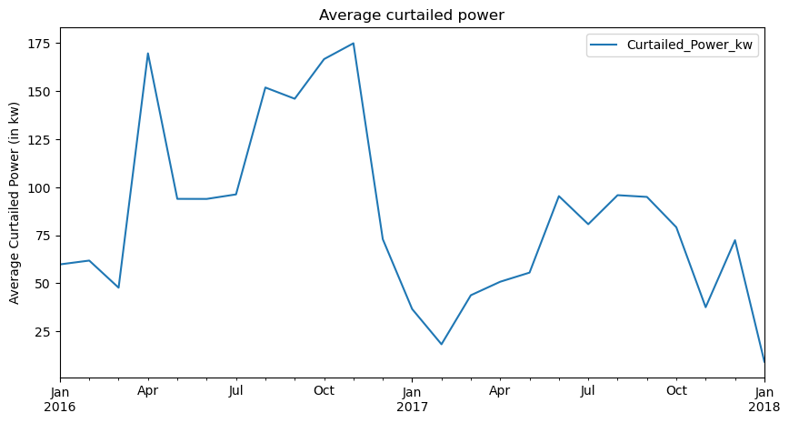

```python
# Curtailed Power - VISUALISATION
power_month_avg = turbine_telemetry_cur.resample('ME').mean()
power_month_avg.plot(y='Curtailed_Power_kw', use_index=True, figsize = (10,5))
plt.xlabel("")
plt.ylabel("Average Curtailed Power (in kw)")
plt.title("Average curtailed power")
plt.show()
```

Furthermore, the following statistics summarize the estimated curtailed energy.

```python
# Mean curtailed power
print("Average curtailed power:",round(np.mean(turbine_telemetry_cur["Curtailed_Power_kw"]),2),'KW')

print("Standard deviation of curtailed power:",round(np.std(turbine_telemetry_cur["Curtailed_Power_kw"]),2), 'KW')

print("Average theoretical maximum power:", round(np.mean(turbine_telemetry_cur["Max_Power_kw"]),2), 'KW')

## Percentage of power curtailed in 2017
_2017 = turbine_telemetry_cur['2017-01-01':'2018-01-01']
print("Percentage of power curtailed in 2017:",round(_2017["Curtailed_Power_kw"].sum() / _2017["Max_Power_kw"].sum()*100,2),'%')

## Percentage of power curtailed in 2016
_2016 = turbine_telemetry_cur['2016-01-01':'2017-01-01']
print("Percentage of power curtailed in 2016:", round(_2016["Curtailed_Power_kw"].sum() / _2017["Max_Power_kw"].sum()*100,2),'%')
```

```
Average curtailed power: 88.38 KW
Standard deviation of curtailed power: 229.9 KW
Average theoretical maximum power: 438.95 KW
Percentage of power curtailed in 2017: 13.87 %
Percentage of power curtailed in 2016: 25.02 %
```

A key insight from the curtailment analysis is that the average curtailed power (88.38 kW) is relatively low when compared to its standard deviation (229.9 kW). This high variability suggests significant fluctuations in the curtailment levels over time, likely driven by mismatches in supply and demand within specific intervals. Additionally, when compared to the average theoretical maximum power (438.95 kW), the curtailed share remains substantial, 25.02% in 2016 and 13.87% in 2017, highlighting the persistent impact of curtailment on overall energy production, particularly in 2016.

#### Data Smoothing for One Turbine

The dataset reflects energy generation for a single wind turbine; however, individual turbine data may be affected by anomalies that do not generalize across the wider turbine population. One such anomaly is *maintenance downtime*, which can significantly reduce output but is a routine requirement for all turbines. If we fail to adjust for periods when this specific turbine is offline due to maintenance, our energy estimates, when scaled up, will be biased for that time period.

To address this, we take the following approach:

- **Identify** extended periods where the turbine produces no power despite high wind speeds, indicating potential maintenance or malfunction.
- **Impute** these gaps using the output that would be expected under normal operation, based on the mean wind-to-power model.
- **Redistribute** the inferred downtime evenly across the year to reflect a realistic and generalized maintenance schedule for a fleet of turbines.

This procedure helps ensure the turbine's output is treated as representative of a typical turbine, rather than one with atypical outages. We begin by identifying abnormal periods lasting longer than a day.

```python
#inspect if maintenance occur
turbine_telemetry_cur[turbine_telemetry_cur["Power_kw"]==0].head()
```

| Timestamp | Power_kw | Setpoint_kw | Wind_ms | Max_Power_kw | Curtailed_Power_kw |
| --- | --- | --- | --- | --- | --- |
| 2016-01-10 01:15:34 | 0.0 | 900.0 | 25.5 | 894.654676 | 894.654676 |
| 2016-01-10 01:16:34 | 0.0 | 900.0 | 20.3 | 898.838560 | 898.838560 |
| 2016-01-10 01:17:34 | 0.0 | 900.0 | 22.3 | 897.774092 | 897.774092 |
| 2016-01-10 01:18:34 | 0.0 | 900.0 | 18.6 | 899.045203 | 899.045203 |
| 2016-01-10 01:19:34 | 0.0 | 900.0 | 24.2 | 897.105516 | 897.105516 |

To accurately estimate total power generation for Orkney, this downtime must be handled carefully. If left unadjusted, it would imply that all turbines across Orkney were offline during this exact period, an unrealistic assumption, as turbine maintenance schedules are typically staggered. Furthermore, during such maintenance periods, no curtailment occurs, as the turbine is entirely offline.

To address this, we apply the following corrections:

1. Impute expected power output during the maintenance period using the mean wind-to-power model, as if the turbine were operating normally.
2. Distribute the implied energy loss from this downtime uniformly across the year. This reflects a more realistic, evenly spread maintenance impact across the turbine fleet.

This approach ensures maintenance effects are accounted for in a way that avoids overestimating energy loss or misrepresenting curtailment patterns.

```python
# 1. Impute data for the generated power during maintenance (where Power_kw is 0)
turbine_telemetry_cur.loc[turbine_telemetry_cur['Power_kw'] == 0, 'Power_kw'] = turbine_telemetry_cur['Max_Power_kw']
```

```python
# 2. Calculate the potential energy loss during maintenance (where Power_kw was originally 0)
potential_loss = sum(turbine_telemetry_cur.loc[turbine_telemetry_cur['Power_kw'] == turbine_telemetry_cur['Max_Power_kw'], 'Power_kw'])

# 3. Subtract expected power energy loss during maintenance over all time periods
# The potential loss is distributed across all periods, so we divide by the total length of the dataset
turbine_telemetry_cur['Power_kw'] = turbine_telemetry_cur['Power_kw'] - potential_loss / len(turbine_telemetry_cur)

# Also adjust Max_Power_kw in the same way
turbine_telemetry_cur['Max_Power_kw'] = turbine_telemetry_cur['Max_Power_kw'] - potential_loss / len(turbine_telemetry_cur)
```

#### Integral of power/min to estimate curtailed energy with 30-minute intervals

Up to this point, our analysis has been based on data recorded at one-minute intervals. However, to align with the resolution of the residential demand data, we aggregate the power data by computing its integral over time. This allows us to estimate curtailed energy in 30-minute intervals, ensuring consistency between the supply and demand datasets for subsequent analysis.

For the purposes of the analysis, we limit the data to that of the year 2017, in line with the available information for demand.

```python
# Filters the data for the year 2017 (i.e., the year of available demand data)
turbine_curt_energy = turbine_telemetry_cur.loc['2017-01-01':'2018-01-01']
```

**Curtailed Energy**

```python
# Calculates energy in kwh as integral of power in kw - for curtailed power
start = turbine_curt_energy.index[0]
start = start - timedelta(seconds=20)
energy_integral = np.empty((17520,1))


for i in range (17520):

    if len(turbine_curt_energy.loc[start:start + timedelta(minutes=30)]['Curtailed_Power_kw']) == 30:
        energy_integral[i,0]= np.trapz(turbine_curt_energy.loc[start:start + timedelta(minutes=30)]['Curtailed_Power_kw']) / 60

    # When the 30-minute interval does not contain 30 reccords (but more than 0), energy is estimated as the average power * 30
    elif len(turbine_curt_energy.loc[start:start + timedelta(minutes=30)]['Curtailed_Power_kw']) > 0:
        energy_integral[i,0]= (turbine_curt_energy.loc[start:start + timedelta(minutes=30)]['Curtailed_Power_kw'].mean() * 30) / 60

    # When the 30-minute interval does not contain any reccords, energy is taken is equivalent to the preceding 30-minute interval
    else:
        energy_integral[i,0]= energy_integral[i-1,0]

    start = start + timedelta(minutes=30)
```

**Potential Maximum Energy Generation**

```python
# Calculates energy in kwh as integral of power in kw - for maximum power
start = turbine_curt_energy.index[0]
start = start - timedelta(seconds=20)
energy_integral_max = np.empty((17520,1))


for i in range (17520):

    if len(turbine_curt_energy.loc[start:start + timedelta(minutes=30)]['Max_Power_kw']) == 30:
        energy_integral_max[i,0]= np.trapz(turbine_curt_energy.loc[start:start + timedelta(minutes=30)]['Max_Power_kw']) / 60

    # When the 30-minute interval does not contain 30 reccords (but more than 0), energy is estimated as the average power * 30
    elif len(turbine_curt_energy.loc[start:start + timedelta(minutes=30)]['Max_Power_kw']) > 0:
        energy_integral_max[i,0]= (turbine_curt_energy.loc[start:start + timedelta(minutes=30)]['Max_Power_kw'].mean() * 30) / 60

    # When the 30-minute interval does not contain any reccords, energy is taken is equivalent to the preceding 30-minute interval
    else:
        energy_integral_max[i,0]= energy_integral_max[i-1,0]

    start = start + timedelta(minutes=30)
```

**Actual Energy Generation**

```python
# Calculates energy in kwh as integral of power in kw - for actual power
start = turbine_curt_energy.index[0]
start = start - timedelta(seconds=20)
energy_integral_act = np.empty((17520,1))


for i in range (17520):

    if len(turbine_curt_energy.loc[start:start + timedelta(minutes=30)]['Power_kw']) == 30:
        energy_integral_act[i,0]= np.trapz(turbine_curt_energy.loc[start:start + timedelta(minutes=30)]['Power_kw']) / 60

    # When the 30-minute interval does not contain 30 reccords (but more than 0), energy is estimated as the average power * 30
    elif len(turbine_curt_energy.loc[start:start + timedelta(minutes=30)]['Power_kw']) > 0:
        energy_integral_act[i,0]= (turbine_curt_energy.loc[start:start + timedelta(minutes=30)]['Power_kw'].mean() * 30) / 60

    # When the 30-minute interval does not contain any reccords, energy is taken is equivalent to the preceding 30-minute interval
    else:
        energy_integral_act[i,0]= energy_integral_act[i-1,0]

    start = start + timedelta(minutes=30)
```

**Summarising all Data Together**

```python
# Summarises all calculations in a data frame
start = turbine_curt_energy.index[0]
start = start - timedelta(seconds=20)
timestamps = []

for i in range(17520):
    timestamps.append(start + timedelta(minutes=30))
    start = start + timedelta(minutes=30)

supply_curtailment = np.column_stack((timestamps, energy_integral[:,0],energy_integral_max[:,0], energy_integral_act[:,0]))
```

The table below summarises the energy calculations for curtailment, potential maximum generation, and actual generation.

```python
# Cleans and organises the new turbine_energy dataframe
supply_curtailment = pd.DataFrame(supply_curtailment)
supply_curtailment.columns = ['Timestamp', 'Curtailed_Energy_integral_kwh', 'Max_Energy_integral_kwh', 'Actual_Energy_integral_kwh']
supply_curtailment = supply_curtailment.set_index('Timestamp')
supply_curtailment['Curtailed_Energy_integral_kwh'] = supply_curtailment['Curtailed_Energy_integral_kwh'].astype(float, errors = 'raise')
supply_curtailment['Max_Energy_integral_kwh'] = supply_curtailment['Max_Energy_integral_kwh'].astype(float, errors = 'raise')
supply_curtailment['Actual_Energy_integral_kwh'] = supply_curtailment['Actual_Energy_integral_kwh'].astype(float, errors = 'raise')
supply_curtailment = supply_curtailment.round(decimals = 4)
supply_curtailment.head()
```

| Timestamp | Curtailed_Energy_integral_kwh | Max_Energy_integral_kwh | Actual_Energy_integral_kwh |
| --- | --- | --- | --- |
| 2017-01-01 00:30:00 | 3.3418 | 404.5232 | 407.5699 |
| 2017-01-01 01:00:00 | 2.6401 | 408.6638 | 409.5199 |
| 2017-01-01 01:30:00 | 0.6571 | 408.7583 | 411.9115 |
| 2017-01-01 02:00:00 | 0.0000 | 408.0047 | 414.3449 |
| 2017-01-01 02:30:00 | 0.0000 | 423.4856 | 428.2016 |

The figure below depics the behaviour of curtailed energy throughout the year 2017.

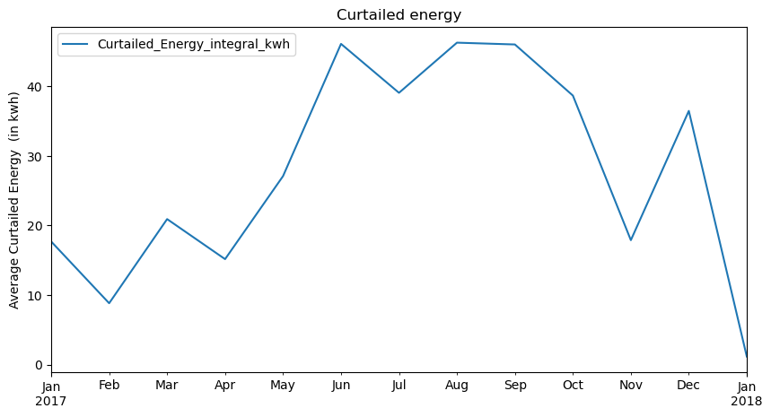

```python
# Curtailed Energy - VISUALISATION
energy_month_avg = supply_curtailment.resample('ME').mean()
energy_month_avg.plot(y='Curtailed_Energy_integral_kwh', use_index=True, figsize=(10,5))
plt.xlabel("")
plt.ylabel("Average Curtailed Energy  (in kwh)")
plt.title("Curtailed energy")
plt.show()
```

```python
# Total curtailed energy for the year 2017 in GWh for one turbine
supply_curtailment['Curtailed_Energy_integral_kwh'].sum()/1000000
```

```
0.5289149216
```

After adjustments, the total energy curtailed for the Rousay turbine in the year 2017 is **0.5289 GWh**.

#### Aggregating Curtailed Energy from One Turbine to 500 Turbines

To produce a realistic estimate of total curtailment, we consider geographical dispersion by accounting for the variation in historical annual average wind speeds across nine representative locations in Orkney: Burray, Flotta, Hoy, Rousay, Shapinsay, Westray, Eday, Stronsay, and Sanday. These locations host community-owned turbines that are consistent in capacity (900 kW), making them suitable proxies for the broader turbine population.

This approach ensures that the final curtailed energy estimate reflects not only the number of turbines but also the spatial variation in wind resources across the Orkney Islands.

```python
supply_curtailment['total_Rousay']= supply_curtailment['Curtailed_Energy_integral_kwh']*60
supply_curtailment['total_Burray']= supply_curtailment['Curtailed_Energy_integral_kwh']*60*(7.97/9.89)
supply_curtailment['total_Flotta']= supply_curtailment['Curtailed_Energy_integral_kwh']*60*(5.44/9.89)
supply_curtailment['total_Hoy']= supply_curtailment['Curtailed_Energy_integral_kwh']*60*(5.44/9.89)
supply_curtailment['total_Shapinsay']= supply_curtailment['Curtailed_Energy_integral_kwh']*60*(7.97/9.89)
supply_curtailment['total_Westray']= supply_curtailment['Curtailed_Energy_integral_kwh']*60*(8.79/9.89)
supply_curtailment['total_Eday']= supply_curtailment['Curtailed_Energy_integral_kwh']*60*(8.38/9.89)
supply_curtailment['total_Stronsay']= supply_curtailment['Curtailed_Energy_integral_kwh']*60*(6.93/9.89)
supply_curtailment['total_Sanday']= supply_curtailment['Curtailed_Energy_integral_kwh']*60*(6.93/9.89)
```

```python
supply_curtailment['total_all']= supply_curtailment['total_Rousay']+supply_curtailment['total_Burray']+supply_curtailment['total_Flotta']+supply_curtailment['total_Hoy']+supply_curtailment['total_Shapinsay']+supply_curtailment['total_Westray']+supply_curtailment['total_Eday']+supply_curtailment['total_Stronsay']+supply_curtailment['total_Sanday']
supply_curtailment.head()
```

| Timestamp | Curtailed_Energy_integral_kwh | Max_Energy_integral_kwh | Actual_Energy_integral_kwh | total_Rousay | total_Burray | total_Flotta | total_Hoy | total_Shapinsay | total_Westray | total_Eday | total_Stronsay | total_Sanday | total_all |
| --- | --- | --- | --- | --- | --- | --- | --- | --- | --- | --- | --- | --- | --- |
| 2017-01-01 00:30:00 | 3.3418 | 404.5232 | 407.5699 | 200.508 | 161.582281 | 110.289537 | 110.289537 | 161.582281 | 178.206807 | 169.894544 | 140.497517 | 140.497517 | 1373.348020 |
| 2017-01-01 01:00:00 | 2.6401 | 408.6638 | 409.5199 | 158.406 | 127.653774 | 87.131308 | 87.131308 | 127.653774 | 140.787537 | 134.220655 | 110.996317 | 110.996317 | 1084.976991 |
| 2017-01-01 01:30:00 | 0.6571 | 408.7583 | 411.9115 | 39.426 | 31.772014 | 21.686293 | 21.686293 | 31.772014 | 35.040904 | 33.406459 | 27.626105 | 27.626105 | 270.042188 |
| 2017-01-01 02:00:00 | 0.0000 | 408.0047 | 414.3449 | 0.000 | 0.000000 | 0.000000 | 0.000000 | 0.000000 | 0.000000 | 0.000000 | 0.000000 | 0.000000 | 0.000000 |
| 2017-01-01 02:30:00 | 0.0000 | 423.4856 | 428.2016 | 0.000 | 0.000000 | 0.000000 | 0.000000 | 0.000000 | 0.000000 | 0.000000 | 0.000000 | 0.000000 | 0.000000 |

Consequently, the total curtailed energy of a *representative Orkney wind turbine* is estimated to be **0.4347 GWh** in 2017.

```python
# Total curtailed energy for the year 2017 in GWh for a representative Orkney turbine
(supply_curtailment['total_all'].sum()/1000000)/500
```

```
0.4347263513348918
```

Furthermore, we want to understand how curtailed energy relates to both potential maximum energy generation and actual energy generated, as this relationship highlights the scale of unrealised energy and the business opportunity for Kaluza. Using the integration approach described earlier for maximum potential and actual generation, the plot below shows the total curtailment opportunity in the Orkney Islands.

The potential energy (orange line) represents the energy that could be produced if there were no curtailment. In contrast, the actual energy generated (blue line) accounts for all adjustments and assumptions made in our analysis. The clear gap between these two lines indicates the extent of energy curtailed. Closing this gap presents a lucrative opportunity for Kaluza.

To visualise the Curtailment, Max Potential Energy, and Actual Generated Energy across all days of the year and across all 30-minute intervals, please refer to **Appendix A (Energy By Time)**. The appendix provides detailed plots that illustrate the variation and gaps between these metrics, offering a comprehensive view of the curtailment patterns throughout the year.

```python
# Divides the information of actual vs potential energy in each location
supply_vs = supply_curtailment.copy()
supply_vs['max_Rousay']= supply_vs['Max_Energy_integral_kwh']*60
supply_vs['max_Burray']= supply_vs['Max_Energy_integral_kwh']*60*(7.97/9.89)
supply_vs['max_Flotta']= supply_vs['Max_Energy_integral_kwh']*60*(5.44/9.89)
supply_vs['max_Hoy']= supply_vs['Max_Energy_integral_kwh']*60*(5.44/9.89)
supply_vs['max_Shapinsay']= supply_vs['Max_Energy_integral_kwh']*60*(7.97/9.89)
supply_vs['max_Westray']= supply_vs['Max_Energy_integral_kwh']*60*(8.79/9.89)
supply_vs['max_Eday']= supply_vs['Max_Energy_integral_kwh']*60*(8.38/9.89)
supply_vs['max_Stronsay']= supply_vs['Max_Energy_integral_kwh']*60*(6.93/9.89)
supply_vs['max_Sanday']= supply_vs['Max_Energy_integral_kwh']*60*(6.93/9.89)
```

```python
supply_vs['total_max']= supply_vs['max_Rousay']+supply_vs['max_Burray']+supply_vs['max_Flotta']+supply_vs['max_Hoy']+supply_vs['max_Shapinsay']+supply_vs['max_Westray']+supply_vs['max_Eday']+supply_vs['max_Stronsay']+supply_vs['max_Sanday']
supply_vs['dif'] = supply_vs['total_max'] - supply_vs['total_all']
```

```python
# Organises and cleans the dataframe of potential energy vs. actual energy in GWh
supply_vs_avg = supply_vs[['dif', 'total_max']]
supply_vs_avg = supply_vs_avg.resample('ME').sum()
supply_vs_avg = supply_vs_avg.iloc[:12,:]
supply_vs_avg['total_max'] = supply_vs_avg['total_max'] / 1000000
supply_vs_avg['dif'] = supply_vs_avg['dif'] / 1000000
```

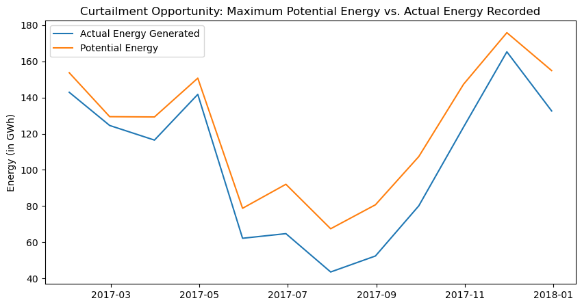

```python
# Total energy potential vs total energy produced - VISUALIZATION
plt.figure(figsize=(10,5))
plt.plot(supply_vs_avg.index, supply_vs_avg['dif'], label = 'Actual Energy Generated')
plt.plot(supply_vs_avg.index, supply_vs_avg['total_max'], label = 'Potential Energy')
plt.xlabel("")
plt.ylabel("Energy (in GWh)")
plt.legend()
plt.title('Curtailment Opportunity: Maximum Potential Energy vs. Actual Energy Recorded')
plt.show()
```

# 2. Demand

In order to estimate a final curtailment reduction potential from the demand side, we begin by analysing the dataset at hand and identify trends and patterns.

```python
resident_demand = pd.read_csv("residential_demand.csv", parse_dates=['Timestamp'], index_col = 0)
resident_demand.head()
```

| Timestamp | Demand_mean_kw | N_households |
| --- | --- | --- |
| 2017-01-01 00:00:00 | 0.220106 | 5428 |
| 2017-01-01 00:30:00 | 0.205945 | 5429 |
| 2017-01-01 01:00:00 | 0.189090 | 5429 |
| 2017-01-01 01:30:00 | 0.173118 | 5429 |
| 2017-01-01 02:00:00 | 0.159051 | 5429 |

We find that, for the year 2017, the `Demand_mean_kw` column reflects the average household electricity demand at each 30-minute timestamp across a representative sample in the Orkney Islands. This demand is contextualised by the `N_households` column, which indicates the number of households included in the sample. However, since `N_households` only represents the sample size and not the total number of households in Orkney, our subsequent analysis focuses exclusively on `Demand_mean_kw` to assess consumption trends and align them with energy generation data.

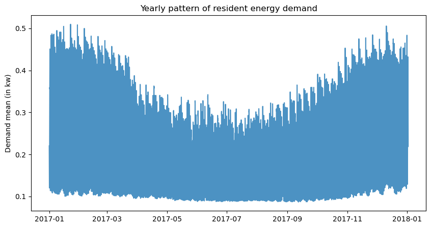

```python
# Yearly pattern
plt.figure(figsize=(10,5))
plt.plot(resident_demand.index, resident_demand['Demand_mean_kw'], alpha = 0.8)
plt.ylabel('Demand mean (in kw)')
plt.title('Yearly pattern of resident energy demand')
plt.show()
```

Most broadly, we identify a yearly pattern of electricity demand, with a clear trough during the summer months, unsurprising given reduced household energy needs as temperatures rise. Additionally, the demand curve exhibits a consistent oscillating pattern throughout the year, suggesting the presence of intra-year periodicity.

#### Seasonal Patterns

To investigate these subtler trends more closely, we next examine seasonal variations in demand, segmenting the data into spring, summer, autumn, and winter. This allows us to better understand how consumption behaviour shifts over time and provides deeper insight into potential alignment with renewable energy generation.

To contextualize our analysis with respect to the entire Orkney Islands, we scale the monthly mean demand figures based on the average number of households. While the dataset provides demand (`Demand_mean_kw`) across a sample of households, we refer to the **[Economic Review 2017](https://www.orkney.gov.uk/media/l5zio0cj/economic_review_2017.pdf)** by the Orkney Islands Council, which reports an average of 10,385 households in Orkney in 2017.

Thus, we multiply the sample-based monthly average demand per household by 10,385 to obtain a robust estimate of the total residential electricity demand across Orkney, enabling a more accurate comparison with regional supply and curtailment figures.

```python
monthly_mean_demand = resident_demand.resample('ME').mean()
monthly_mean_demand["Total Demand"] = monthly_mean_demand["Demand_mean_kw"] * 10385
spring_monthly_mean_demand = monthly_mean_demand[1:4]
summer_monthly_mean_demand = monthly_mean_demand[4:7]
autumn_monthly_mean_demand = monthly_mean_demand[7:10]
winter_monthly_mean_demand = monthly_mean_demand.iloc[[0, 10, 11]]
```

```python
spring_demand = spring_monthly_mean_demand.sum()["Total Demand"]
summer_demand = summer_monthly_mean_demand.sum()["Total Demand"]
autumn_demand = autumn_monthly_mean_demand.sum()["Total Demand"]
winter_demand = winter_monthly_mean_demand.sum()["Total Demand"]
total_demand = spring_demand + summer_demand + autumn_demand + winter_demand

spring_prop = spring_demand/total_demand
summer_prop = summer_demand/total_demand
autumn_prop = autumn_demand/total_demand
winter_prop = winter_demand/total_demand
```

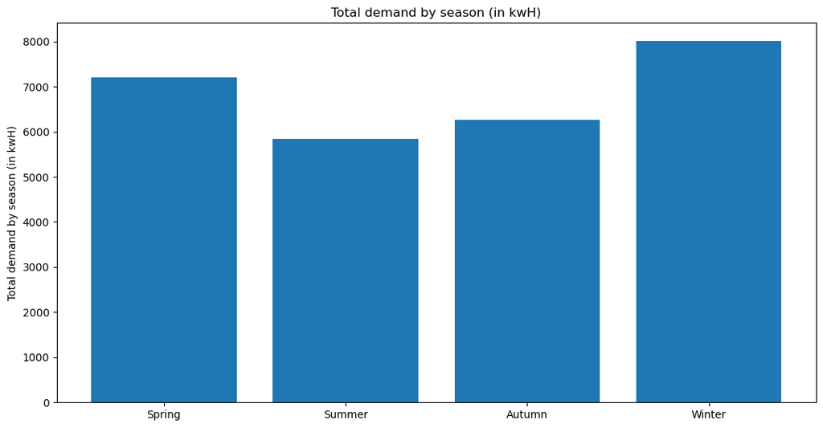

```python
fig = plt.figure(figsize=(10,5))
ax = fig.add_axes([0,0,1,1])
lables = ['Spring', 'Summer', 'Autumn', 'Winter']
data = [spring_demand,summer_demand,autumn_demand,winter_demand]
ax.bar(lables,data)
plt.ylabel("Total demand by season (in kwH)")
plt.title("Total demand by season (in kwH)")
plt.show()
```

Apart from analyzing the demand seasonally, we also examine the monthly mean demand to determine whether it is more insightful to segment the year into the traditional four seasons or instead group months into just high-demand and off-demand periods. This distinction helps simplify the modeling if monthly trends show consistent demand levels within broader periods, and it ensures that our supply-demand matching and curtailment strategies align more closely with actual consumption behavior.

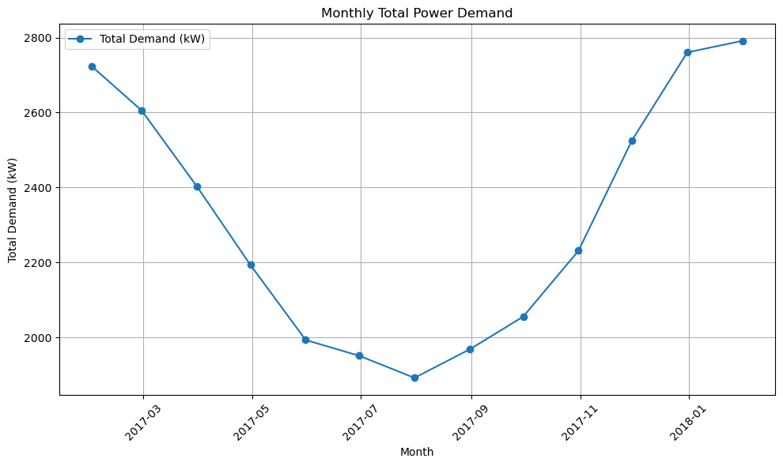

```python
# Plotting the monthly demand
plt.figure(figsize=(10, 6))

# Plot the total demand for each month
plt.plot(monthly_mean_demand.index, monthly_mean_demand['Total Demand'], label='Total Demand (kW)', marker='o')

# Adding labels and title
plt.xlabel('Month')
plt.ylabel('Total Demand (kW)')
plt.title('Monthly Total Power Demand')

# Display the legend
plt.legend()

# Rotate x-axis labels for readability
plt.xticks(rotation=45)

# Display grid and improve layout
plt.grid(True)
plt.tight_layout()

# Show the plot
plt.show()
```

Based on the plot, we adopt a simplified segmentation approach and divide the year into high-demand and off-demand periods, instead of the traditional four seasons.

- **High-demand months:** October, November, December, January, February, March, April
- **Off-demand months:** May, June, July, August, September

This grouping reflects the clear increase in average household energy consumption during colder months, which aligns with heating needs and reduced daylight, and provides a more practical basis for our subsequent analysis.

In the charts above, we observe an aggregated representation of the yearly demand patterns. As anticipated, total demand drops during the summer months, while peaking in winter, reflecting seasonal changes in heating and lighting needs. This confirms that electricity demand is influenced not only by temperature but also by household routines. Moreover, as hinted earlier, demand also fluctuates throughout the day. To gain deeper insights into this temporal variation, we now examine the average daily demand profile, as illustrated in the plot below.

```python
resident_demand["Time"] = 0
times = [i for i in resident_demand.index]
for index, timestamp in enumerate(times):
    resident_demand.loc[timestamp, "Time"] = pd.to_datetime(resident_demand.index[index]).time()
```

```python
times_dict={}
for i in np.unique(resident_demand["Time"]):
    times_dict[i]= np.mean(resident_demand[resident_demand["Time"]==i]["Demand_mean_kw"])
times_list=[]
for w in resident_demand["Time"]:
    #print(w)
    average_demand = times_dict[w]
    times_list.append(average_demand)
resident_demand["Mean_Demand"]= times_list
```

```python
t = pd.DataFrame({"Time":[str(time) for time in times_dict.keys()], "Average Demand":[d for d in times_dict.values()]})
```

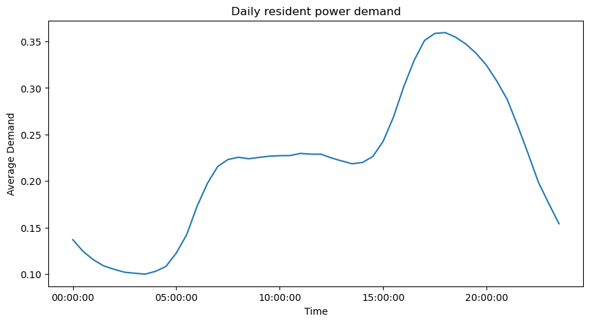

```python
plt.figure(figsize=(10,5))
plt.plot(t["Time"], t["Average Demand"])
plt.xlabel("Time")
plt.ylabel("Average Demand")
x_ticks = ["00:00:00", "05:00:00", "10:00:00", "15:00:00", "20:00:00"]
plt.xticks(ticks=x_ticks)
plt.title("Daily resident power demand")
plt.show()
```

Recognising these variations is crucial for accurately estimating curtailment reduction potential, as both daily and seasonal demand fluctuations must be incorporated into the analysis.

Finally, while this average daily curve provides a useful overview, it is important to remember that actual demand varies day by day. This variability is explored in more depth in **Appendix B (Demand)**, which illustrates a range of daily demand profiles.

#### Demand vs. Curtailment

We then converted the demand power (kW) into energy (kWh) by integrating over each 30-minute interval. Since energy is the product of power and time, this was achieved by multiplying the average demand power at each timestamp by 0.5 hours. This transformation allows for a consistent comparison with curtailed and potential maximum energy estimates, all of which are measured in kilowatt-hours (kWh).

```python
# Assuming 'Mean_Demand' is in kW, convert to kWh by multiplying by 0.5 hours (30 minutes)
resident_demand['Energy_kWh'] = resident_demand['Demand_mean_kw'] * 0.5
```

```python
resident_demand = resident_demand.drop('Time', axis = 1)

# Resample the data by month and calculate the mean for each month
monthly_mean_energy_demand = resident_demand.resample('ME').mean()
monthly_mean_energy_demand["Total Energy Demand"] = monthly_mean_energy_demand["Energy_kWh"] * 10385
```

```python
supply_curtailment = supply_curtailment.drop('Time', axis = 1)

total_curtailed_month_avg = supply_curtailment.resample('ME').mean()
```

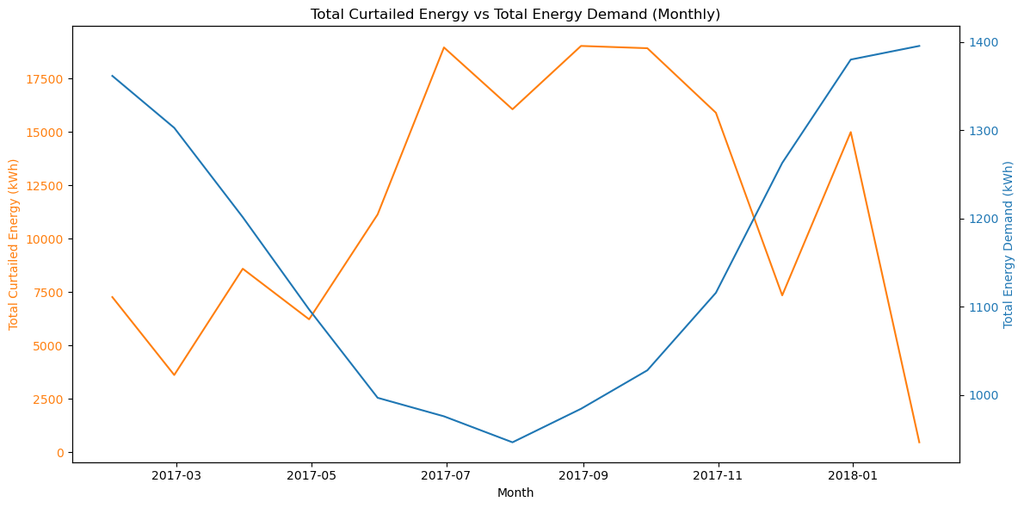

```python
# Create a plot with two y-axes
fig, ax1 = plt.subplots(figsize=(12, 6))

# Plot total curtailed energy on the left y-axis
ax1.plot(total_curtailed_month_avg.index, total_curtailed_month_avg['total_all'], label='Total Curtailed Energy (kWh)', color='#ff7f0e')
ax1.set_xlabel('Month')
ax1.set_ylabel('Total Curtailed Energy (kWh)', color='#ff7f0e')
ax1.tick_params(axis='y', labelcolor='#ff7f0e')

# Create a second y-axis for energy demand
ax2 = ax1.twinx()
ax2.plot(monthly_mean_energy_demand.index, monthly_mean_energy_demand['Total Energy Demand'], label='Total Energy Demand (kWh)', color='#1f77b4')
ax2.set_ylabel('Total Energy Demand (kWh)', color='#1f77b4')
ax2.tick_params(axis='y', labelcolor='#1f77b4')

# Adding a title
plt.title('Total Curtailed Energy vs Total Energy Demand (Monthly)')

# Display the plot
fig.tight_layout()
plt.show()
```

This plot illustrates the monthly total curtailed energy (orange line, left y-axis) in relation to the total energy demand (blue line, right y-axis) throughout 2017. Several key observations emerge:

- **Inverse Relationship:** There is a clear inverse relationship between curtailed energy and energy demand. During the summer months (around June to September), curtailed energy reaches its peak, while energy demand is at its lowest. Conversely, in winter months (January to March and November to December), curtailed energy drops and demand increases.
- **Curtailment Opportunity:** This dynamic highlights a significant mismatch between supply and demand—a core insight that supports the business opportunity for curtailment optimization. Especially in summer, substantial amounts of potential energy are curtailed while demand is low, indicating excess generation capacity that could be better utilized.
- **Systemic Imbalance:** These patterns underscore the importance of demand-side flexibility and intelligent energy distribution solutions like those potentially offered by Kaluza. By aligning periods of high curtailment with mechanisms to shift or store demand, significant efficiency gains could be unlocked.

To observe this relationship in finer detail across all days of the year at 30-minute intervals, refer to **Appendix B (Demand)**.

# 3. Demand-Response Penetration

This section presents a two-part analytical framework to support the design of a scalable and impact-driven residential Demand Response (DR) program. The objective was twofold:

To design a scalable DR program, we estimated how many households would need to participate at varying levels of ambition (10% to 50% of technical potential). Using annual consumption data segmented by household type (Low, Medium, High) and a 50% flexibility factor (based on controllable loads like heating and EVs), we quantified total DR potential. For each DR target level, we then converted the required kW into the number of participating households—creating a roadmap from technical goals to operational scale.

Methodology:

- Defined DR levels as percentages of total annual demand: `[0.1, 0.2, 0.3, 0.5]`.
- For each DR level, calculated the required energy reduction in kilowatts.
- Divided each DR target by the **average annual demand per household** to determine the number of participating households needed.
- Results were plotted using a **bar chart**, with each bar representing a different DR level and its corresponding household count.
- Numerical annotations were added above each bar for clarity and communication value.

## 3.1 Energy Demand Reduction Modeling

$$D_{m,\text{reduced}} = D_m \times (1 - r)$$

```python
demand_sample_data = {
    'Timestamp': pd.date_range(start='2017-01-01', periods=12, freq='M'),
    'Demand_mean_kw': [0.8, 0.85, 0.9, 1.0, 1.05, 1.1, 1.2, 1.1, 1.0, 0.95, 0.9, 0.85]  # Sample kW values
}
resident_demand = pd.DataFrame(demand_sample_data).set_index('Timestamp')
monthly_mean_demand = resident_demand.resample('M').mean()
monthly_mean_demand["Total Demand (kW)"] = monthly_mean_demand["Demand_mean_kw"] * 10385

# Calculate total annual demand
total_annual_demand_kw = monthly_mean_demand["Total Demand (kW)"].sum()
print("The total annual demand:", total_annual_demand_kw)
```

```
The total annual demand: 121504.5
```

In this step, we calculated the total annual energy demand by first creating a DataFrame with average monthly demand per household `(Demand_mean_kw)` across 12 months in 2017. We then multiplied these values by the total number of households (10,385) to get the total demand per month for the entire population. Finally, we summed the monthly totals using .sum() to compute the total annual demand in kilowatts, which was stored in the variable total_annual_demand_kw.

#### Multiple DR penetration levels

```python
# Calculate DR reduction for each month across multiple DR penetration levels
dr_levels = [0.1, 0.2, 0.3, 0.5]  # 10%, 20%, 30%, 50%

# Create a new DataFrame to store the reductions
dr_reductions = monthly_mean_demand[["Total Demand (kW)"]].copy()

# Apply reductions
for level in dr_levels:
    dr_reductions[f"Reduced @ {int(level*100)}% DR (kW)"] = dr_reductions["Total Demand (kW)"] * (1 - level)

# Reformat the DataFrame for display without ACE Tools
dr_reductions_rounded = dr_reductions.round(2)
dr_reductions_rounded.reset_index(inplace=True)
# dr_reductions_rounded.head(12)
```

To estimate the total annual residential energy demand, we created a synthetic dataset representing the average monthly power usage per household (in kW) across a 12-month period. Using pandas, we generated timestamps for each month in 2017 and assigned corresponding average demand values. We then scaled these per-household values by the total number of households to compute the total monthly demand across the entire population. Finally, we summed these monthly values to obtain the total annual energy demand in kilowatts, which served as a baseline for applying different levels of demand response reductions in subsequent analysis.

#### Monthly chronological demand and DR

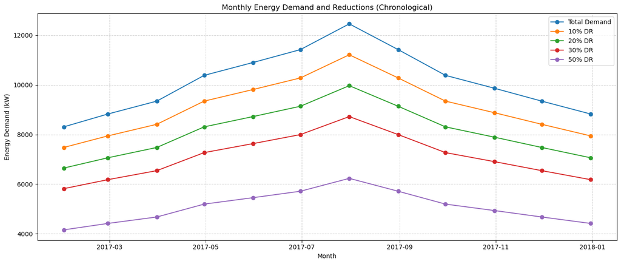

```python
# Time-based line chart
plt.figure(figsize=(14, 6))

plt.plot(dr_reductions_rounded['Timestamp'], dr_reductions_rounded["Total Demand (kW)"], label='Total Demand', marker='o')
plt.plot(dr_reductions_rounded['Timestamp'], dr_reductions_rounded["Reduced @ 10% DR (kW)"], label='10% DR', marker='o')
plt.plot(dr_reductions_rounded['Timestamp'], dr_reductions_rounded["Reduced @ 20% DR (kW)"], label='20% DR', marker='o')
plt.plot(dr_reductions_rounded['Timestamp'], dr_reductions_rounded["Reduced @ 30% DR (kW)"], label='30% DR', marker='o')
plt.plot(dr_reductions_rounded['Timestamp'], dr_reductions_rounded["Reduced @ 50% DR (kW)"], label='50% DR', marker='o')

plt.title("Monthly Energy Demand and Reductions (Chronological)")
plt.xlabel("Month")
plt.ylabel("Energy Demand (kW)")
plt.legend()
plt.grid(True, linestyle='--', alpha=0.6)
plt.tight_layout()
plt.show()
```

## 3.2 Participation Requirement Estimation

To quantify the scale of participation required to deliver flexible load capacity, we first estimated the total DR potential available in the residential sector. This was based on:

- Segmented household demand (Low, Medium, High usage)
- Total household count: $$H_{\text{total}} = 10{,}385$$
- A controllable load assumption of 50%, i.e., $$\text{DR}_{\text{potential}} = 0.5 \times \text{Total Annual Demand}$$

We then evaluated how many households would be required to meet a given DR target level using the formula:

$$\text{Households Required} = \frac{\text{Total Annual Demand} \times \text{DR Level}}{\text{Average Household Annual Demand}}$$

This allowed us to translate DR targets (e.g., 10%, 30%, 50%) into **concrete recruitment thresholds**, forming a roadmap from strategic ambition to operational execution.

#### Demand Response Households Requirement

```python
# Given:
# - Total DR reduction needed = let's take 50% DR of annual demand as maximum scenario
# - Total annual demand (from earlier): 121,504.5 kW
# - 50% DR target = 60,752.25 kW reduction
# - Average household demand per year (estimated from data): total annual / 10385 households

total_annual_demand = 121504.5  # kW
dr_target_kw = total_annual_demand * 0.5
estimated_households = 10385
avg_household_annual_kw = total_annual_demand / estimated_households

# Now, calculate how many households are needed to deliver the DR target
households_needed = dr_target_kw / avg_household_annual_kw
print("The total households needed:", households_needed)
```

```
The total households needed: 5192.5
```

In this step, we estimated the number of households required to achieve a 50% demand response (DR) reduction of the total annual energy demand. Starting with a known annual demand value of `121,504.5 kW`, we calculated the 50% DR target as 60,752.25 kW. To determine how many households would need to contribute to reach this target, we first estimated the average annual demand per household by dividing the total demand by the total number of households (10,385). Finally, we divided the DR target by the average household demand to get the required number of participating households. The result gives us a clear benchmark for planning DR program scale.

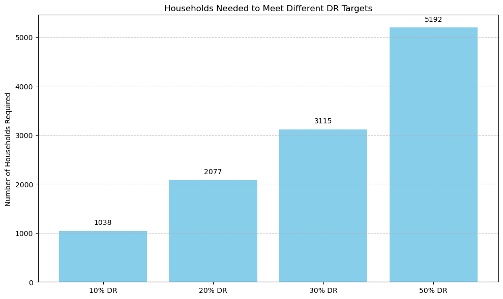

```python
# Calculate households required for each DR level
dr_levels = [0.1, 0.2, 0.3, 0.5]
households_required = [(total_annual_demand * level) / avg_household_annual_kw for level in dr_levels]

# Plotting
plt.figure(figsize=(10, 6))
plt.bar([f"{int(level*100)}% DR" for level in dr_levels], households_required, color='skyblue')
plt.ylabel("Number of Households Required")
plt.title("Households Needed to Meet Different DR Targets")
plt.grid(axis='y', linestyle='--', alpha=0.7)

# Annotate bars
for i, value in enumerate(households_required):
    plt.text(i, value + 100, f"{int(value)}", ha='center', va='bottom')

plt.tight_layout()
plt.show()
```

In this step, we calculated and visualized how many households are needed to achieve different levels of demand response (DR) participation—specifically at 10%, 20%, 30%, and 50% of the total annual energy demand. Using the previously calculated values for total annual demand and average annual demand per household, we applied each DR level as a percentage of total demand and then divided by the per-household average to estimate the number of households required. These values were plotted as a bar chart, with each bar representing a DR level and its corresponding household count. We added numerical annotations above each bar for clarity. This visualization clearly shows the scaling relationship between DR targets and required participation, supporting strategic decisions on phased rollout and community engagement.

#### Incentive costs at Various DR Levels and Payout Rates

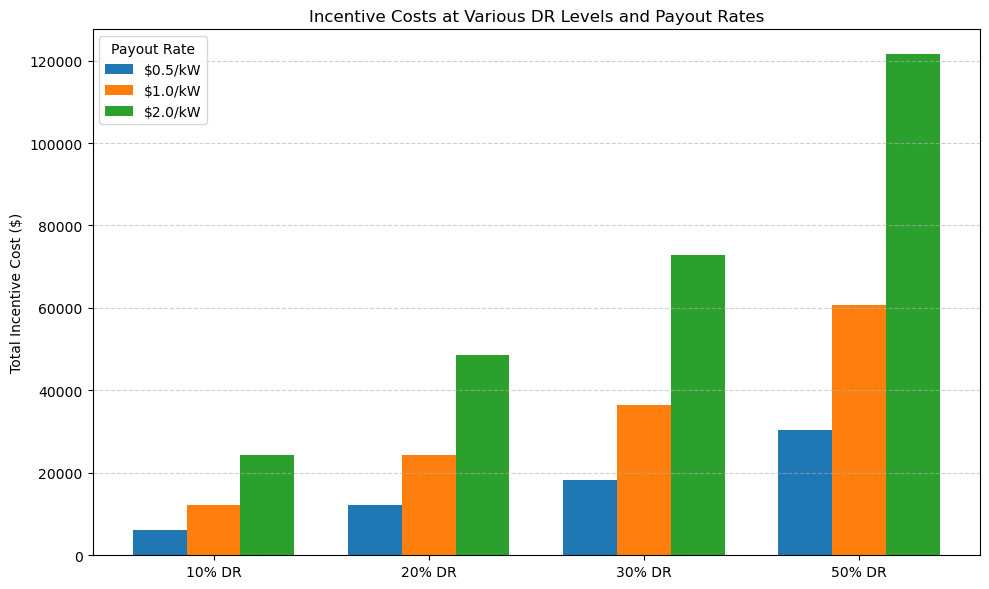

```python
# Assume some incentive rate per kW reduced annually
# Let's try a few different incentive values per kW reduction
incentive_rates = [0.5, 1.0, 2.0]  # $ per kW reduction

# Calculate cost at each DR level
incentive_costs = {}
for rate in incentive_rates:
    incentive_costs[f"${rate}/kW"] = [(total_annual_demand * level) * rate for level in dr_levels]

# Plot
x_labels = [f"{int(level*100)}% DR" for level in dr_levels]
x = range(len(dr_levels))
bar_width = 0.25

plt.figure(figsize=(10, 6))
for i, (label, costs) in enumerate(incentive_costs.items()):
    plt.bar([p + i*bar_width for p in x], costs, width=bar_width, label=label)

plt.xticks([p + bar_width for p in x], x_labels)
plt.ylabel("Total Incentive Cost ($)")
plt.title("Incentive Costs at Various DR Levels and Payout Rates")
plt.legend(title="Payout Rate")
plt.grid(axis='y', linestyle='--', alpha=0.6)
plt.tight_layout()
plt.show()
```

In this step, we modeled the total incentive cost required to support different levels of demand response (DR) participation—10%, 20%, 30%, and 50%—across various payout rates per kW of reduced demand. We defined three incentive rates: `$0.50, $1.00, and $2.00 per kW`, and calculated the total program cost for each rate by multiplying the DR energy reduction (as a percentage of total annual demand) by the respective rate. The results were visualized in a grouped bar chart, where each cluster of bars shows the incentive cost for a specific DR level under the three different payout scenarios. This helped illustrate how DR incentive budgets scale with both participation and payout generosity, providing Kaluza with a framework to balance impact and affordability when designing compensation structures.

#### 50% DR Potential by household type

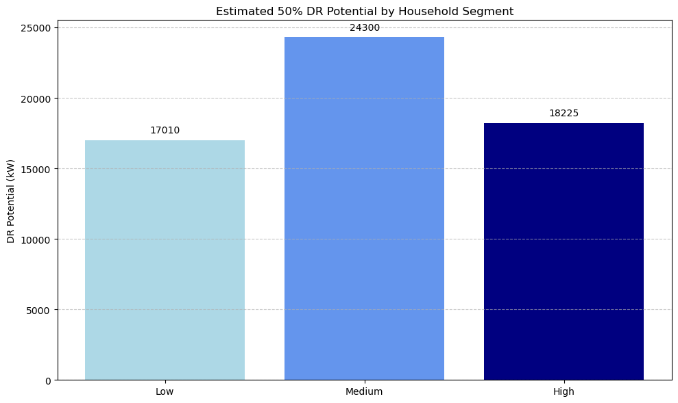

|  | Segment | Households | Avg Usage (kW/year) | Total Segment Demand (kW) | 50% DR Potential (kW) |
| --- | --- | --- | --- | --- | --- |
| 0 | Low | 4154 | 8.2 | 34021.3 | 17010.6 |
| 1 | Medium | 4154 | 11.7 | 48601.8 | 24300.9 |
| 2 | High | 2077 | 17.5 | 36451.3 | 18225.7 |

```python
# Parameters for adoption modeling
years = [f"Year {i}" for i in range(1, 6)]
household_adoption_percent = [0.1 * i for i in range(1, 6)]  # 10% to 50%
total_households = 10385
target_dr_percent = 0.5  # 50% DR

# Simulate household segments: Low, Medium, High usage (with example proportions and multipliers)
household_segments = {
    "Low": {"percent": 0.4, "usage_factor": 0.7},
    "Medium": {"percent": 0.4, "usage_factor": 1.0},
    "High": {"percent": 0.2, "usage_factor": 1.5},
}

# Average annual demand per household (baseline from earlier)
avg_annual_kw = avg_household_annual_kw

# Calculate DR contribution by segment
segment_data = {
    "Segment": [],
    "Households": [],
    "Avg Usage (kW/year)": [],
    "Total Segment Demand (kW)": [],
    "50% DR Potential (kW)": []
}

for seg, vals in household_segments.items():
    count = int(vals["percent"] * total_households)
    usage = avg_annual_kw * vals["usage_factor"]
    total = count * usage
    dr_potential = total * 0.5

    segment_data["Segment"].append(seg)
    segment_data["Households"].append(count)
    segment_data["Avg Usage (kW/year)"].append(round(usage, 1))
    segment_data["Total Segment Demand (kW)"].append(round(total, 1))
    segment_data["50% DR Potential (kW)"].append(round(dr_potential, 1))

segment_df = pd.DataFrame(segment_data)

# Plotting
plt.figure(figsize=(10, 6))
plt.bar(segment_df["Segment"], segment_df["50% DR Potential (kW)"], color=['lightblue', 'cornflowerblue', 'navy'])
plt.title("Estimated 50% DR Potential by Household Segment")
plt.ylabel("DR Potential (kW)")
plt.grid(axis='y', linestyle='--', alpha=0.7)

# Annotate bars
for i, val in enumerate(segment_df["50% DR Potential (kW)"]):
    plt.text(i, val + 500, f"{int(val)}", ha='center')

plt.tight_layout()
plt.show()

segment_df
```

For each segment, we:

- Calculated the number of households using its percentage of the total population.
- Multiplied the baseline average demand by the segment-specific usage factor to get average usage per household.

**Calculated total segment demand = households × average usage**

This output presents the final breakdown of demand response (DR) potential across three household segments—Low, Medium, and High—based on segment size and average annual energy usage. The Medium segment, with 4,154 households averaging 11.7 kW/year, offers the highest total DR potential at approximately **24,300 kW**, followed by the High segment (~18,226 kW) and the Low segment (~17,011 kW). Although High-usage households consume more energy individually (17.5 kW/year), their smaller population results in lower aggregate DR compared to the Medium group. This analysis confirms that while all segments contribute meaningfully, **Medium-usage households provide the greatest scalable DR capacity**, making them the optimal initial target for Kaluza’s programs. The results support a segmentation-based rollout strategy that balances system impact with inclusivity and operational feasibility.

# 4. Stakeholder Pricing Benefits

In designing an effective demand response (DR) program, pricing sits at the core of behavioural activation and economic alignment. Our pricing strategy builds up from the source, Wind Farmers, and cascades through the value chain to Energy Providers and finally to Consumers. The goal is to understand how pricing at each level can trigger demand shifts that reduce curtailment, improve system efficiency, and preserve profitability across all stakeholders.

**1. Wind Farmer Pricing and Supply Conditions**: We begin by analyzing how wind generation pricing patterns, especially during high-curtailment periods, affect downstream decision-making. When wind supply is abundant and prices are suppressed (often nearing zero or even negative during curtailment windows), this represents a clear signal that cheap, clean energy is available but underutilized. Understanding these price trends provides the foundation for downstream pricing strategy. It quantifies when and how much renewable energy is at risk of curtailment, setting the stage for energy providers to design responsive retail tariffs that absorb this surplus energy.

**2. Energy Provider Pricing Response**: Building on wind farmer price signals, energy providers (such as utilities or DR platforms like Kaluza) can adjust retail electricity tariffs dynamically, lowering prices during periods of surplus generation. The idea is to translate low upstream costs into consumer-facing incentives that drive behavioural change. Our model simulates how providers can pass through a portion of these cost savings to end-users while still maintaining margin. Providers benefit by monetizing energy that would otherwise be lost, improving system utilization without significant revenue sacrifice.

**3. Consumer Demand Response to Dynamic Pricing**: With provider pricing adjusted to reflect wind conditions, we then analyze how consumers respond to these pricing signals. Drawing on demand elasticity models, we observe that even modest, well-timed price drops can shift load significantly, particularly among households with controllable devices (e.g., EVs, heat pumps, hot water tanks). This leads to a flattened demand curve, higher off-peak consumption, and lower evening peaks, all achieved without asking consumers to reduce overall usage. Instead, they are incentivized to shift, not sacrifice. The demand uplift during discounted periods reduces renewable energy curtailment and enhances grid flexibility.

**4. Consumer Benefit Realization**: Lastly, we quantify the net benefit to consumers. Through time-of-use (ToU) incentives, households lower their bills by consuming energy during cheaper windows. Importantly, this comes without loss of comfort or service quality, especially when load shifting is automated via smart devices. From a financial perspective, consumers see measurable savings. From a behavioural lens, they engage in flexibility programs more willingly. The combination of economic incentive + automation makes the proposition scalable and user-friendly.

By linking wind generation pricing to provider tariffs and ultimately to consumer behaviour, we create a pricing cascade that unlocks value at every stage of the energy chain. This strategy not only helps integrate more renewable energy and reduce curtailment, but also ensures that each stakeholder, **wind farmers, providers, and consumers**, benefits economically. In doing so, we set the foundation for a resilient, responsive, and inclusive energy system.

### 4.1 Wind Farmer Pricing Strategy

To build an effective foundation for demand activation, we first analyze the pricing behaviour of wind farmers across seasonal patterns. Prices are initially segmented into two key periods:

- **High-demand season (October to April):** Average price of 17.7p/kWh
- **Off-demand season (May to September):** Average price of 15.7p/kWh

```python
# Ensure index is a datetime index
supply_vs.index = pd.to_datetime(supply_vs.index)

# Define the seasons
high_demand_season = [10, 11, 12, 1, 2, 3, 4]  # Oct to Apr
off_season = [5, 6, 7, 8, 9]                  # May to Sep

# Extract month from the index
supply_vs['month'] = supply_vs.index.month

# Create the price column based on month
supply_vs['Price'] = supply_vs['month'].apply(
    lambda m: 0.177 if m in high_demand_season else 0.157
)
```

```python
# Normalize total_all to 0–1 scale
demand_pressure = (supply_vs['total_all'] - supply_vs['total_all'].min()) / \
                  (supply_vs['total_all'].max() - supply_vs['total_all'].min())

# Create variation ±0.005 based on pressure (could be demand or temperature proxy)
supply_vs['Price_var'] = round(supply_vs['Price'] + (demand_pressure - 0.5) * 0.01, 3)

supply_vs['Price_var'] = supply_vs['Price_var'].apply(
    lambda m: 0.147 if m < 0.147 else m
)
```

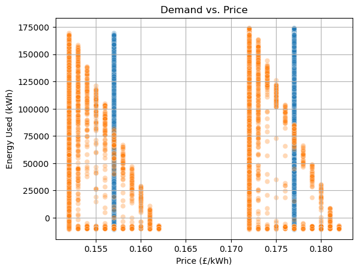

```python
sns.scatterplot(data=supply_vs, x='Price', y='dif', alpha = 0.3)
sns.scatterplot(data=supply_vs, x='Price_var', y='dif', alpha = 0.3)
plt.title("Demand vs. Price")
plt.xlabel("Price (£/kWh)")
plt.ylabel("Energy Used (kWh)")
plt.grid(True)
plt.show()
```

We estimate a causal model of demand using the following specification:

$$\text{Demand (dif)} \sim \text{Price\_var} + \text{C(month}) + \text{C(hour})$$

where:

- $\text{Price}_{\text{var}}$ = price with introduced variation
- $\text{C(month}), \text{C(hour})$ = fixed effects to control for seasonal and diurnal patterns

This allows us to isolate the marginal impact of price variation on demand, independent of time-based confounders.

```python
supply_vs['hour'] = supply_vs.index.hour

model_varied = smf.ols('dif ~ Price_var + C(month) + C(hour)', data=supply_vs).fit()
```

Based on model insights, we propose a tiered pricing recommendation for wind farmers:

- Reduce 1p during low curtailment hours
- Reduce 1.5p during moderate curtailment
- Reduce 2p during high curtailment periods

These targeted reductions act as demand triggers, incentivizing consumption when excess renewable generation is most at risk.

```python
q1 = supply_vs['total_all'].quantile(0.33)
q2 = supply_vs['total_all'].quantile(0.66)

def assign_discount(val):
    if val <= q1:
        return 0.01  # low curtailment → 1p reduction
    elif val <= q2:
        return 0.015  # medium curtailment → 1.5p
    else:
        return 0.02  # high curtailment → 2p

supply_vs['Price_Reduction'] = supply_vs['total_all'].apply(assign_discount)
supply_vs['Price_sim'] = round(supply_vs['Price_var'] - supply_vs['Price_Reduction'], 3)
```

Simulating demand using these adjusted prices, we observe the strongest uplift in demand during the summer months (April to September), particularly across midday hours (8:00 to 16:00), when curtailment typically peaks. This confirms the effectiveness of dynamic pricing in aligning demand with supply-side constraints, and provides a data-backed framework for wind farmers to monetize excess generation while supporting grid stability.

```python
# Recalculate predicted demand and clip to feasible bounds
supply_vs['Predicted_demand'] = model_varied.predict(supply_vs.assign(Price_var=supply_vs['Price_sim']))
supply_vs['Predicted_demand'] = supply_vs['Predicted_demand'].clip(lower=0)
supply_vs['Predicted_demand'] = supply_vs[['Predicted_demand', 'total_max']].min(axis=1)
```

### 4.2 Energy Provider Pricing Strategy

To align energy provider pricing with wind farmer rates, we segmented prices into three quantiles: 16.5p (Q1), 16.8p (Q2), and 17.2p (Q3). We then introduced a dynamic pricing mechanism with a $\pm$0.005 variation based on curtailment pressure, setting a floor price of 16.5p.

```python
q1 = supply_vs['Price_var'].quantile(0.33)
q2 = supply_vs['Price_var'].quantile(0.66)

def map_to_consumer_price(p):
    if p <= q1:
        return 0.165
    elif p <= q2:
        return 0.168
    else:
        return 0.172  # Adjusted to ensure higher bin is used

# Use the actual historical producer price to assign customer price
supply_vs['Actual_Consumer_price'] = supply_vs['Price_var'].apply(map_to_consumer_price)

# Normalize total_all to 0–1 scale
demand_pressure = (supply_vs['total_all'] - supply_vs['total_all'].min()) / \
                  (supply_vs['total_all'].max() - supply_vs['total_all'].min())

# Create variation ±0.005 based on pressure (could be demand or temperature proxy)
supply_vs['Consumer_Price_var'] = round(supply_vs['Actual_Consumer_price'] + (demand_pressure - 0.5) * 0.01, 3)

supply_vs['Consumer_Price_var'] = supply_vs['Consumer_Price_var'].apply(
    lambda m: 0.165 if m < 0.165 else m
)
```

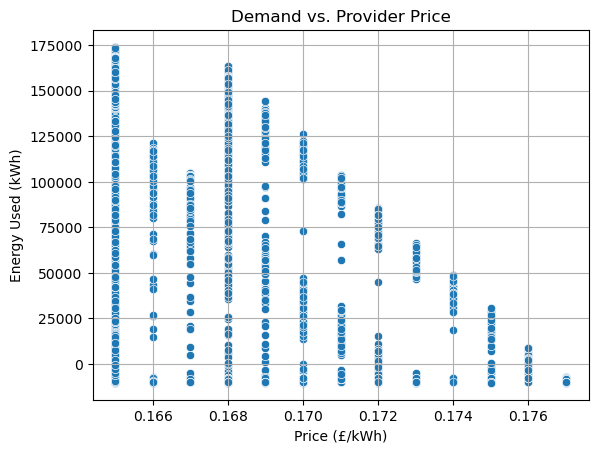

```python
sns.scatterplot(data=supply_vs, x='Consumer_Price_var', y='dif')
plt.title("Demand vs. Provider Price")
plt.xlabel("Price (£/kWh)")
plt.ylabel("Energy Used (kWh)")
plt.grid(True)
plt.show()
```

Using the causal model

$$\text{Demand (dif)} \sim \text{Consumer\_Price\_var} + \text{C(month}) + \text{C(hour})$$

we found a strong negative relationship between consumer price and demand (coefficient: -6.153e+06), reinforcing that even small price reductions can significantly raise household consumption.

```python
consumer_model = smf.ols('dif ~ Consumer_Price_var + C(hour) + C(month)', data=supply_vs).fit()
```

These reductions were not arbitrary, they were based on the marginal impact of price on demand from our model (Consumer_Price_var coefficient: -6.153e+06) and tailored to reflect curtailment pressure levels. The goal was to set lower retail prices during high curtailment periods to stimulate demand and absorb excess generation.

```python
# Try 3 quantile bins instead of 4
q1_sim = supply_vs['Actual_Consumer_price'].quantile(0.33)
q2_sim = supply_vs['Actual_Consumer_price'].quantile(0.66)

def map_to_consumer_price_sim(p):
    if p <= q1_sim:
        return 0.152 #0.165 - 0.013
    elif p <= q2_sim:
        return 0.153 #0.168 - 0.015
    else:
        return 0.154 #0.172 - 0.017

# Use the actual historical producer price to assign customer price
supply_vs['Consumer_price_sim'] = supply_vs['Actual_Consumer_price'].apply(map_to_consumer_price_sim)
```

By lowering prices during these periods, providers can better align consumption with supply surpluses, reducing curtailment. To quantify this impact, we compared monthly curtailed energy volumes before and after the revised pricing strategy. The results showed substantial recovery of previously wasted energy, confirming the effectiveness of dynamic retail pricing in driving responsive, consumer-led grid balancing.

```python
supply_vs['Predicted_Household_Demand'] = consumer_model.predict(supply_vs.assign(Consumer_Price_var=supply_vs['Consumer_price_sim']))
supply_vs['Predicted_Household_Demand'] = supply_vs['Predicted_Household_Demand'].clip(lower=0)
supply_vs['Predicted_Household_Demand'] = supply_vs[['total_max', 'Predicted_Household_Demand']].min(axis=1)

# Step 3: Curtailment avoided at household level
supply_vs['New_Household_Curtailment'] = supply_vs['total_max'] - supply_vs['Predicted_Household_Demand']
supply_vs['Curtailment_Avoided'] = supply_vs['total_all'] - supply_vs['New_Household_Curtailment']
```

### 4.3 Curtailment Difference on New Demand

We then compare the monthly curtailed energy before and after applying the revised energy provider pricing strategy, illustrating the impact of increased consumer demand on reducing curtailment.

The blue line represents the original average curtailed energy across months under the baseline demand model, while the orange line shows the new curtailed energy after adjusting demand in response to reduced consumer prices.

We observe a notable drop in curtailed energy across nearly all months—especially between May and October, which aligns with previously identified high-curtailment and low-demand periods. This reduction is a direct result of increased household consumption during hours when energy would otherwise be wasted.

The results confirm that even modest price drops, when timed correctly, can lead to significant system-level gains by absorbing surplus wind energy and flattening the curtailment curve throughout the year.

```python
consumer_average_curtailment_by_month = supply_vs.groupby('Month')['New_Household_Curtailment'].mean()
old_average_curtailment_by_month = supply_vs.groupby('Month')['total_all'].mean()
```

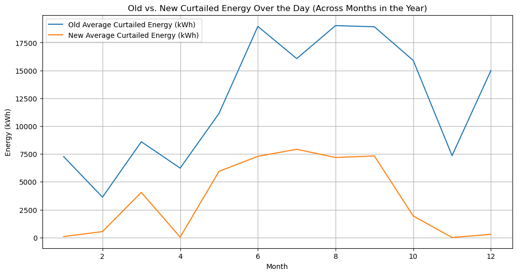

```python
# Plotting the three curves on the same plot
plt.figure(figsize=(12, 6))

# Plot the average old curtailed energy
plt.plot(old_average_curtailment_by_month.index, old_average_curtailment_by_month, label='Old Average Curtailed Energy (kWh)')

# Plot the average curtailed energy
plt.plot(consumer_average_curtailment_by_month.index, consumer_average_curtailment_by_month, label='New Average Curtailed Energy (kWh)')

# Adding labels and title
plt.xlabel('Month')
plt.ylabel('Energy (kWh)')
plt.title('Old vs. New Curtailed Energy Over the Day (Across Months in the Year)')

# Display legend
plt.legend()

# Display grid for better visibility
plt.grid(True)

# Tight layout to ensure labels and title fit
# plt.tight_layout()

# Show the plot
plt.show()
```

### 4.4 5-Year Forecast for Stakeholder Benefits

This model simulates how demand response (DR) adoption affects wind farmers, energy providers, and consumers over five years.

We basically simulates adjusted prices for each year and calculates household demand (for penetration) under old and new prices. Then we estimate revenue, cost, and profit for:

- Wind farmers (selling to providers)
- Energy providers (selling to consumers)
- Consumers (based on cost per household)

Despite increasing prices, greater demand from DR adoption leads to:

- Higher profits for wind farmers and providers
- Lower average costs per household
- Reduced curtailment due to better energy utilization

```python
# adoption_plan = [0.1, 0.05, 0.15, 0.07, 0.2]

# adoption_plan = [0.071, 0.061, 0.052, 0.049, 0.05]  ---> BASED ON MARKETING STRAT BY ISHAN AND ADITI

adoption_plan = [0.08, 0.1, 0.08, 0.07, 0.06]

# Flat pence increments per year (in £)
price_increments_wind = [0.000, 0.005, 0.010, 0.015, 0.020]  # Years 1–5
price_increments_provider = [0.000, 0.01, 0.015, 0.020, 0.025]  # Years 1–5

base_wind_farmer_cost = 45000 * 500

demand_df = []
farmer_df = []
provider_df = []
consumer_df = []

for year, penetration in enumerate(adoption_plan, 1):
    year_tag = f'Year_{year}'
    price_bump_wind = price_increments_wind[year - 1]  # 0-based index
    price_bump_provider = price_increments_provider[year - 1]  # 0-based index

    # Adjust prices dynamically per year
    adjusted_price_var = supply_vs['Price_var'] + price_bump_wind
    adjusted_consumer_price_var = supply_vs['Actual_Consumer_price'] + price_bump_provider
    adjusted_price_sim = supply_vs['Price_sim'] + price_bump_wind
    adjusted_consumer_price = supply_vs['Consumer_price_sim'] + price_bump_provider

    # Household demand for the year (scaled from predicted)
    old_demand = (supply_vs['dif'] * (penetration))  # scale based on base model's 10%
    demand = supply_vs['Predicted_Household_Demand'] * (penetration)  # scale based on base model's 10%

    if year > 1:
        old_demand = old_demand + demand_df[year - 2]['Total Demand Old (kWh)'] * 1.01
        demand = demand + demand_df[year - 2]['Total Demand New (kWh)'] * 1.01

    peak_month = demand.groupby(demand.index.month).sum().idxmax()

    # Consumer costs
    consumer_old_demand_cost = old_demand * adjusted_consumer_price_var
    consumer_old_demand_new_cost = old_demand * adjusted_consumer_price
    consumer_old_demand_diff = consumer_old_demand_cost.sum() - consumer_old_demand_new_cost.sum()

    consumer_new_demand_old_cost = demand * adjusted_consumer_price_var
    consumer_new_demand_cost = demand * adjusted_consumer_price
    consumer_new_demand_diff = consumer_new_demand_old_cost.sum() - consumer_new_demand_cost.sum()

    # consumer_old_cost = demand * adjusted_consumer_price_var
    # consumer_new_total_cost = demand * adjusted_consumer_price
    # consumer_net_diff = consumer_old_cost.sum() - consumer_new_total_cost.sum()

    # Energy providers sell this at Consumer_price_sim

    provider_old_old_revenue = old_demand * adjusted_consumer_price_var
    provider_new_old_revenue = demand * adjusted_consumer_price_var
    provider_old_new_revenue = old_demand * adjusted_consumer_price
    provider_new_new_revenue = demand * adjusted_consumer_price

    provider_old_old_cost = old_demand * adjusted_price_var
    provider_new_old_cost = demand * adjusted_price_var
    provider_old_new_cost = old_demand * adjusted_price_sim
    provider_new_new_cost = demand * adjusted_price_sim

    provider_old_profit = provider_old_old_revenue - provider_old_old_cost
    provider_new_profit = provider_new_new_revenue - provider_new_new_cost

    # Wind farmers sell to providers at Price_sim
    wind_farmers_annual_cost = base_wind_farmer_cost * (1 + 0.02)**(year - 1)
    windfarmer_old_revenue = old_demand * adjusted_price_var #supply_vs['Price_var']
    windfarmer_revenue = demand * adjusted_price_sim
    wind_farmers_old_profit = windfarmer_old_revenue.sum() - wind_farmers_annual_cost
    wind_farmers_profit = windfarmer_revenue.sum() - wind_farmers_annual_cost

    demand_df.append({
        'Year_Num': year,
        'Year': year_tag,
        'Household Penetration %': penetration + demand_df[year - 2]['Household Penetration %'] if year > 1 else penetration,
        'Total Demand Old (kWh)': old_demand,
        'Total Demand New (kWh)': demand,
        'Month': peak_month
    })

    farmer_df.append({
        'Year_Num': year,
        'Year': year_tag,
        'Household Penetration %': penetration + farmer_df[year - 2]['Household Penetration %'] if year > 1 else penetration,

        'Wind Farmer Old Price': round(adjusted_price_var.mean(), 3),
        'Wind Farmer New Price': round(adjusted_price_sim.mean(), 3),
        'Wind Farmer Old Revenue (£)': windfarmer_old_revenue.sum(),
        'Wind Farmer Revenue (£)': windfarmer_revenue.sum(),
        'Wind Farmer Old Profit (£)': wind_farmers_old_profit.sum(),
        'Wind Farmer New Profit (£)': wind_farmers_profit.sum(),
        'Wind Farmet Cost': wind_farmers_annual_cost
    })

    provider_df.append({
        'Year_Num': year,
        'Year': year_tag,
        'Household Penetration %': penetration + provider_df[year - 2]['Household Penetration %'] if year > 1 else penetration,
        'Provider Old Price': round(adjusted_consumer_price_var.mean(), 3),
        'Provider New Price': round(adjusted_consumer_price.mean(), 3),

        'Old Demand - Old Price: Revenue (£)': provider_old_old_revenue.sum(),
        'New Demand - Old Price: Revenue (£)': provider_new_old_revenue.sum(),
        'Old Demand - New Price: Revenue (£)': provider_old_new_revenue.sum(),
        'New Demand - New Price: Revenue (£)': provider_new_new_revenue.sum(),

        'Old Demand - Old Price: Cost (£)': provider_old_old_cost.sum(),
        'New Demand - Old Price: Cost (£)': provider_new_old_cost.sum(),
        'Old Demand - New Price: Cost (£)': provider_old_new_cost.sum(),
        'New Demand - New Price: Cost (£)': provider_new_new_cost.sum(),

        'Provider Old Profit (£)': provider_old_profit.sum(),
        'Provider New Profit (£)': provider_new_profit.sum(),
    })

    consumer_df.append({
        'Year_Num': year,
        'Year': year_tag,
        'Household Penetration %': penetration + consumer_df[year - 2]['Household Penetration %'] if year > 1 else penetration,
        'Consumer Old Demand Cost': consumer_old_demand_cost.sum() / (10385 * (penetration + consumer_df[year - 2]['Household Penetration %'] if year > 1 else penetration)),
        'Consumer Old Demand New Cost': consumer_old_demand_new_cost.sum() / (10385 * (penetration + consumer_df[year - 2]['Household Penetration %'] if year > 1 else penetration)),
        'Consumer Old Demand Diff': consumer_old_demand_diff.sum() / (10385 * (penetration + consumer_df[year - 2]['Household Penetration %'] if year > 1 else penetration)),
        'Consumer New Demand Old Cost': consumer_new_demand_old_cost.sum() / (10385 * (penetration + consumer_df[year - 2]['Household Penetration %'] if year > 1 else penetration)),
        'Consumer New Demand Cost': consumer_new_demand_cost.sum() / (10385 * (penetration + consumer_df[year - 2]['Household Penetration %'] if year > 1 else penetration)),
        'Consumer New Demand Diff': consumer_new_demand_diff.sum() / (10385 * (penetration + consumer_df[year - 2]['Household Penetration %'] if year > 1 else penetration)),
    })

demand_summary = pd.DataFrame(demand_df)
farmer_summary = pd.DataFrame(farmer_df)
provider_summary = pd.DataFrame(provider_df)
consumer_summary = pd.DataFrame(consumer_df)
```

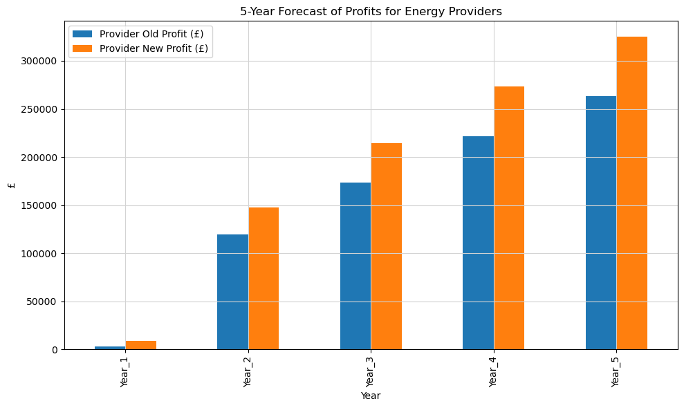

```python
(provider_summary.set_index('Year')[['Provider Old Profit (£)', 'Provider New Profit (£)']] * 0.1).plot(kind='bar', figsize=(10,6))
plt.ylabel('£')
plt.title('5-Year Forecast of Profits for Energy Providers')
plt.grid(True, color = 'lightgrey')
plt.tight_layout()
plt.show()
```

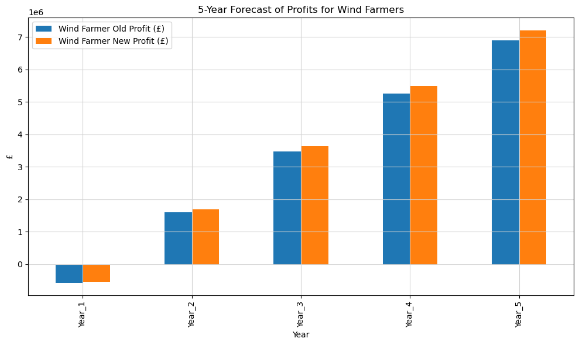

```python
(farmer_summary.set_index('Year')[['Wind Farmer Old Profit (£)', 'Wind Farmer New Profit (£)']] * 0.1).plot(kind='bar', figsize=(10,6))
plt.ylabel('£')
plt.title('5-Year Forecast of Profits for Wind Farmers')
plt.grid(True, color = 'lightgrey')
plt.tight_layout()
plt.show()
```

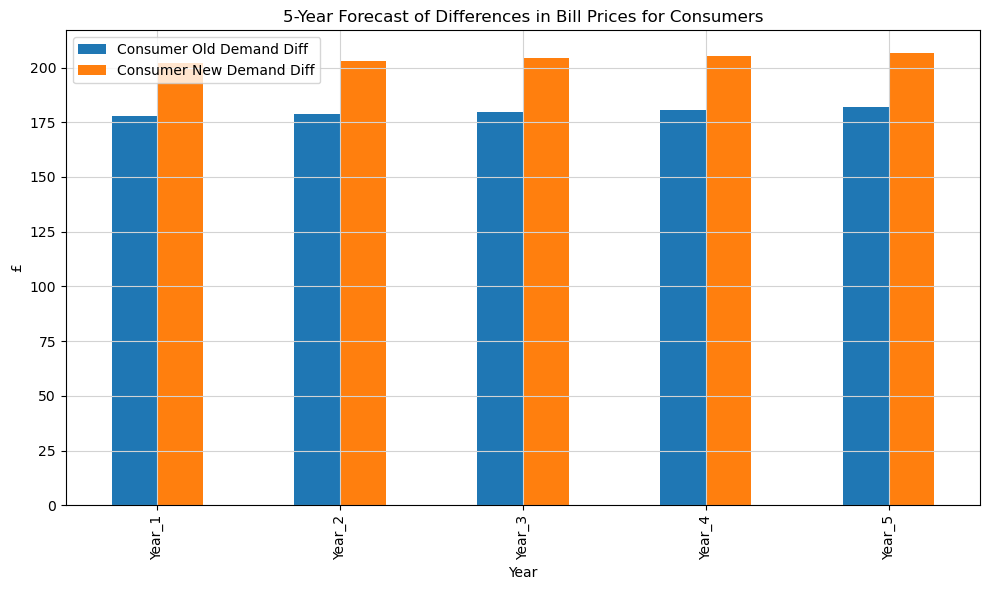

```python
(consumer_summary.set_index('Year')[['Consumer Old Demand Diff', 'Consumer New Demand Diff']] * 0.1).plot(kind='bar', figsize=(10,6))
plt.ylabel('£')
plt.title('5-Year Forecast of Differences in Bill Prices for Consumers')
plt.grid(True, color = 'lightgrey')
plt.tight_layout()
plt.show()
```

# Appendix A - Supply

```python
import numpy as np
import pandas as pd
import matplotlib.pyplot as plt

from sklearn.metrics import mean_squared_error, r2_score
from sklearn.linear_model import LinearRegression
import math
from datetime import timedelta
import warnings
import calendar
warnings.filterwarnings("ignore")
```

#### Missing value Analysis

```python
turbine_telemetry_copy = turbine_telemetry.copy()
turbine_telemetry_copy['Date'] = turbine_telemetry_copy['Timestamp'].dt.date

# Extract full range of dates in dataset
overall_start = turbine_telemetry_copy['Date'].min()
overall_end = turbine_telemetry_copy['Date'].max()

# Generate a DataFrame of expected dates by year
full_date_range = pd.date_range(start=overall_start, end=overall_end, freq='D')
full_date_df = pd.DataFrame({'Date': full_date_range.date})
full_date_df['Year'] = pd.to_datetime(full_date_df['Date']).dt.year

# Mark which dates are present in the data
present_dates = set(turbine_telemetry_copy['Date'].unique())
full_date_df['Is_Present'] = full_date_df['Date'].isin(present_dates)

# Group by year to summarize missing dates and coverage
summary = (
    full_date_df.groupby('Year')
    .agg(
        Start_Date=('Date', 'min'),
        End_Date=('Date', 'max'),
        Total_Days=('Date', 'count'),
        Missing_Days=('Is_Present', lambda x: (~x).sum()),
        Coverage_Days=('Is_Present', lambda x: x.sum())
    )
    .reset_index()
)

# Display summary
print("Year-wise Coverage and Missing Days in Turbine Telemetry:\n")
print(summary)
```

```
Year-wise Coverage and Missing Days in Turbine Telemetry:

   Year  Start_Date    End_Date  Total_Days  Missing_Days  Coverage_Days
0  2015  2015-05-28  2015-12-31         218           187             31
1  2016  2016-01-01  2016-12-31         366             2            364
2  2017  2017-01-01  2017-12-31         365            20            345
3  2018  2018-01-01  2018-01-11          11             0             11
```

#### Minimum Wind Speed Filter

```python
# Filter where power output is exactly at max capacity (900 kW)
mask_max_power = turbine_telemetry['Power_kw'] == 900

# Wind speed range when turbine is capped
min_ws = turbine_telemetry[mask_max_power]['Wind_ms'].min()
max_ws = turbine_telemetry[mask_max_power]['Wind_ms'].max()

print(f"Wind speed range while turbine is capped at 900 kW: {min_ws:.2f} m/s to {max_ws:.2f} m/s")
```

```
Wind speed range while turbine is capped at 900 kW: 11.20 m/s to 30.50 m/s
```

```python
# Filter rows where the turbine is generating power
non_zero_power = turbine_telemetry[turbine_telemetry['Power_kw'] > 0]

# Get the minimum wind speed in those rows
cut_in_speed = non_zero_power['Wind_ms'].min()

print(f"Cut-in wind speed (min wind for non-zero power): {cut_in_speed:.2f} m/s")
```

```
Cut-in wind speed (min wind for non-zero power): 1.90 m/s
```

```python
# Minimum speed for minimum power
mask4 = turbine_telemetry_['Power_kw'] == 10
turbine_telemetry_[mask4]['Wind_ms'].min() # Min speed at which we get 10
```

```
2.6
```

#### Median Model

```python
# Median model calibration
predict_power_dict_median = {}
for i in np.unique(turbine_telemetry_["Wind_ms"]):
    predict_power_dict_median[i] = np.median(turbine_telemetry_[turbine_telemetry_["Wind_ms"] == i]["Power_kw"])

predict_power_list_median = []
for w in turbine_telemetry_["Wind_ms"]:
    p_tmp_median = predict_power_dict_median[w]
    predict_power_list_median.append(p_tmp_median)

turbine_telemetry_["Median_Predicted_Power_kw"] = predict_power_list_median
```

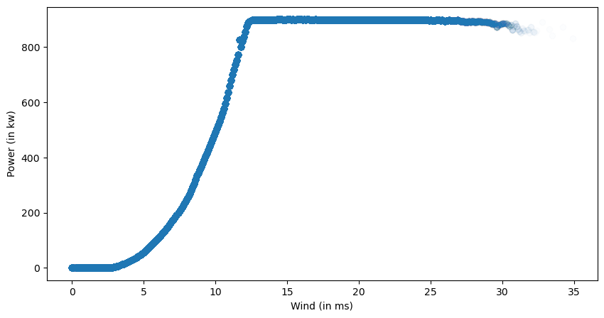

```python
# Median model - VISUALIZATION
plt.figure(figsize=(10, 5))
plt.scatter(turbine_telemetry_["Wind_ms"],turbine_telemetry_["Median_Predicted_Power_kw"], alpha =0.01)
plt.xlabel("Wind (in ms)")
plt.ylabel("Power (in kw)")
plt.show()
```

```python
# Median model RMSE calculation
MSE_avg_Median = mean_squared_error(turbine_telemetry_["Power_kw"], turbine_telemetry_["Median_Predicted_Power_kw"])
RMSE_avg_Median = math.sqrt(MSE_avg_Median)
print("The median model has a RMSE of", round(RMSE_avg_Median,2))
```

```
The median model has a RMSE of 42.37
```

#### Binning Model

```python
bin_edges = pd.interval_range(start=0, freq=0.5, end=31)

# Create bins based on the wind speed data
turbine_telemetry_["Wind_ms_binned"] = pd.cut(turbine_telemetry_["Wind_ms"], bins=bin_edges)

# Calculate the mean or median of Power_kw for each bin
bin_mean_power = turbine_telemetry_.groupby("Wind_ms_binned")["Power_kw"].mean()
bin_median_power = turbine_telemetry_.groupby("Wind_ms_binned")["Power_kw"].median()

# Map the median power back to the original dataframe
turbine_telemetry_["Binned_Mean_Predicted_Power_kw"] = turbine_telemetry_["Wind_ms_binned"].map(bin_mean_power)
turbine_telemetry_["Binned_Median_Predicted_Power_kw"] = turbine_telemetry_["Wind_ms_binned"].map(bin_median_power)
```

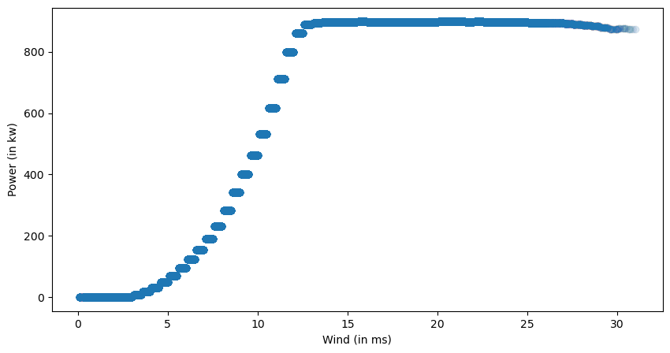

```python
# Binned Mean model - VISUALIZATION
plt.figure(figsize=(10, 5))
plt.scatter(turbine_telemetry_["Wind_ms"],turbine_telemetry_["Binned_Mean_Predicted_Power_kw"], alpha =0.01)
plt.xlabel("Wind (in ms)")
plt.ylabel("Power (in kw)")
plt.show()
```

```python
# Drop rows where either Power_kw or Binned_Mean_Predicted_Power_kw is NaN
turbine_telemetry_clean = turbine_telemetry_.dropna(subset=["Power_kw", "Binned_Mean_Predicted_Power_kw"])

# Now compute the RMSE
Binned_Mean_MSE_avg = mean_squared_error(turbine_telemetry_clean["Power_kw"], turbine_telemetry_clean["Binned_Mean_Predicted_Power_kw"])
Binned_Mean_RMSE_avg = math.sqrt(Binned_Mean_MSE_avg)

print("The Binned Mean model has a RMSE of", round(Binned_Mean_RMSE_avg, 2))
```

```
The Binned Mean model has a RMSE of 44.09
```

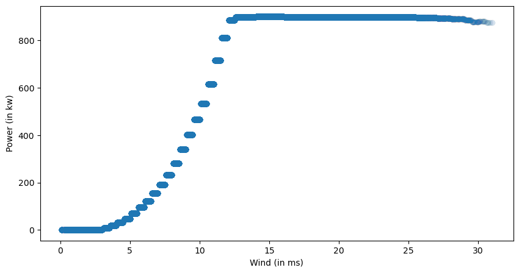

```python
# Binned Median model - VISUALIZATION
plt.figure(figsize=(10, 5))
plt.scatter(turbine_telemetry_["Wind_ms"],turbine_telemetry_["Binned_Median_Predicted_Power_kw"], alpha =0.01)
plt.xlabel("Wind (in ms)")
plt.ylabel("Power (in kw)")
plt.show()
```

```python
# Drop rows where either Power_kw or Binned_Mean_Predicted_Power_kw is NaN
turbine_telemetry_clean = turbine_telemetry_.dropna(subset=["Power_kw", "Binned_Median_Predicted_Power_kw"])

# Now compute the RMSE
Binned_Median_MSE_avg = mean_squared_error(turbine_telemetry_clean["Power_kw"], turbine_telemetry_clean["Binned_Median_Predicted_Power_kw"])
Binned_Median_RMSE_avg = math.sqrt(Binned_Median_MSE_avg)

print("The Binned Median model has a RMSE of", round(Binned_Median_RMSE_avg, 2))
```

```
The Binned Median model has a RMSE of 44.44
```

#### Linear Model

```python
# Prepare data for linear regression
X = turbine_telemetry_[["Wind_ms"]].values.reshape(-1, 1)  # Wind speed as independent variable
y = turbine_telemetry_["Power_kw"].values  # Power as dependent variable

# Create and fit the linear regression model
linear_model = LinearRegression()
linear_model.fit(X, y)

# Use the model to predict power based on wind speed
turbine_telemetry_["Linear_Predicted_Power_kw"] = linear_model.predict(X)
```

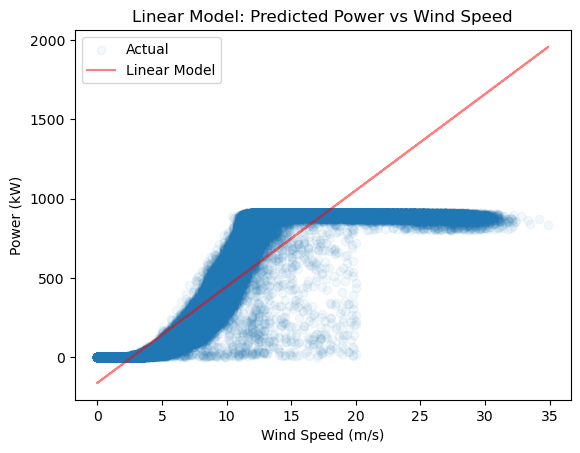

```python
# Plot the result
plt.scatter(turbine_telemetry_["Wind_ms"], turbine_telemetry_["Power_kw"], label="Actual", alpha = 0.05)
plt.plot(turbine_telemetry_["Wind_ms"], turbine_telemetry_["Linear_Predicted_Power_kw"], color="red", alpha = 0.5, label="Linear Model")
plt.xlabel("Wind Speed (m/s)")
plt.ylabel("Power (kW)")
plt.legend()
plt.title("Linear Model: Predicted Power vs Wind Speed")
plt.show()
```

```python
# For the linear model
linear_intercept = linear_model.intercept_
linear_coefficient = linear_model.coef_[0]

print(f"Linear Model Equation: Power_predicted = {linear_intercept:.2f} + ({linear_coefficient:.2f}) * Wind_ms")
```

```
Linear Model Equation: Power_predicted = -163.24 + (60.79) * Wind_ms
```

```python
# For the Linear Model: Predictions
linear_predictions = linear_model.predict(turbine_telemetry_[["Wind_ms"]].values)  # Convert to numpy array

# Calculate RMSE
linear_mse = mean_squared_error(turbine_telemetry_["Power_kw"], linear_predictions)
linear_rmse = math.sqrt(linear_mse)

# Calculate R-squared
linear_r2 = r2_score(turbine_telemetry_["Power_kw"], linear_predictions)

# Print the results
print(f"Linear Model RMSE: {linear_rmse:.2f}")
print(f"Linear Model R-squared: {linear_r2:.2f}")
```

```
Linear Model RMSE: 146.63
Linear Model R-squared: 0.80
```

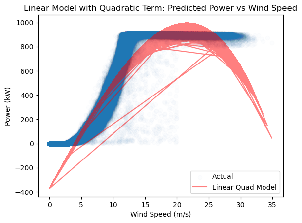

```python
# Add quadratic term to the independent variable
X_quad = np.hstack((X, X**3))  # Add Wind_ms^3 as an additional feature

# Create and fit the linear regression model with quadratic term
linear_model_quad = LinearRegression()
linear_model_quad.fit(X_quad, y)

# Use the model to predict power based on wind speed (with quadratic term)
turbine_telemetry_["Linear_Quad_Predicted_Power_kw"] = linear_model_quad.predict(X_quad)

# Plot the result
plt.scatter(turbine_telemetry_["Wind_ms"], turbine_telemetry_["Power_kw"], label="Actual", alpha = 0.01)
plt.plot(turbine_telemetry_["Wind_ms"], turbine_telemetry_["Linear_Quad_Predicted_Power_kw"], color="red", alpha = 0.5, label="Linear Quad Model")
plt.xlabel("Wind Speed (m/s)")
plt.ylabel("Power (kW)")
plt.legend()
plt.title("Linear Model with Quadratic Term: Predicted Power vs Wind Speed")
plt.show()
```

```python
# For the linear model with quadratic term
linear_quad_intercept = linear_model_quad.intercept_
linear_quad_coefficient_wind = linear_model_quad.coef_[0]
linear_quad_coefficient_wind_sq = linear_model_quad.coef_[1]

print(f"Linear Quadratic Model Equation: Power_predicted = {linear_quad_intercept:.2f} + "
      f"({linear_quad_coefficient_wind:.2f}) * Wind_ms + ({linear_quad_coefficient_wind_sq:.2f}) * Wind_ms^2")
```

```
Linear Quadratic Model Equation: Power_predicted = -371.34 + (95.11) * Wind_ms + (-0.07) * Wind_ms^2
```

```python
# For Quadratic Model: Predictions
linear_quad_predictions = linear_model_quad.predict(np.hstack((turbine_telemetry_[["Wind_ms"]].values,
                                                               turbine_telemetry_[["Wind_ms"]].values**2)))

# Calculate RMSE
linear_quad_mse = mean_squared_error(turbine_telemetry_["Power_kw"], linear_quad_predictions)
linear_quad_rmse = math.sqrt(linear_quad_mse)

# Calculate R-squared
linear_quad_r2 = r2_score(turbine_telemetry_["Power_kw"], linear_quad_predictions)

# Print the results
print(f"Linear Model with Quadratic Term RMSE: {linear_quad_rmse:.2f}")
print(f"Linear Model with Quadratic Term R-squared: {linear_quad_r2:.2f}")
```

```
Linear Model with Quadratic Term RMSE: 237.75
Linear Model with Quadratic Term R-squared: 0.49
```

#### Curtailment, Max Potential, and Actual Energy Generation by Time - 500 Turbines

```python
#supply_curtailment = supply_curtailment.set_index('Timestamp')

# Extract the time from the timestamp and convert to minutes since midnight
supply_curtailment['Time'] = supply_curtailment.index.time
supply_curtailment['Time_in_minutes'] = supply_curtailment.index.hour * 60 + supply_curtailment.index.minute

supply_vs['Time'] = supply_vs.index.time
supply_vs['Time_in_minutes'] = supply_vs.index.hour * 60 + supply_vs.index.minute

# Group by the 'Time_in_minutes' and calculate the mean for each 30-minute interval
average_curtailment_by_time = supply_curtailment.groupby('Time_in_minutes')['total_all'].mean()
average_max_energy_by_time = supply_vs.groupby('Time_in_minutes')['total_max'].mean()
actual_generated_power = average_max_energy_by_time - average_curtailment_by_time

# Convert the numeric time in minutes to hours:minutes format
average_curtailment_by_time.index = [f'{h:02}:{m:02}' for h, m in zip(*divmod(average_curtailment_by_time.index, 60))]
average_max_energy_by_time.index = [f'{h:02}:{m:02}' for h, m in zip(*divmod(average_max_energy_by_time.index, 60))]
```

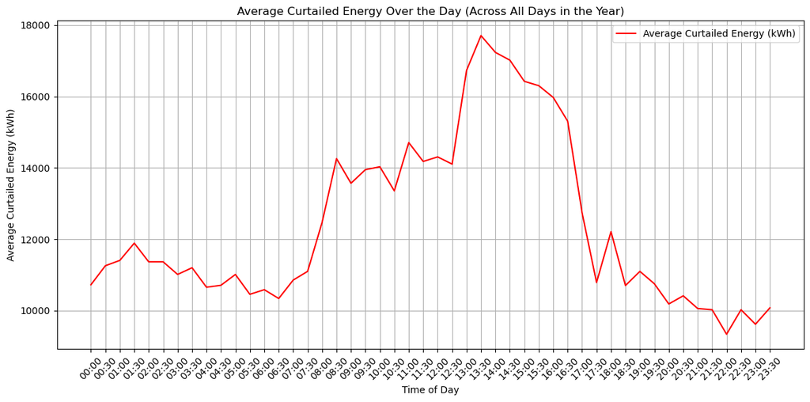

```python
plt.figure(figsize=(12, 6))

# Plot the average curtailed energy per 30-minute time slot
plt.plot(average_curtailment_by_time.index, average_curtailment_by_time, label='Average Curtailed Energy (kWh)', color='red')

# Adding labels and title
plt.xlabel('Time of Day')
plt.ylabel('Average Curtailed Energy (kWh)')
plt.title('Average Curtailed Energy Over the Day (Across All Days in the Year)')

# Display legend
plt.legend()

# Rotate x-axis labels for better readability
plt.xticks(rotation=45)

# Display grid for better visibility
plt.grid(True)

# Tight layout to ensure labels and title fit
plt.tight_layout()

# Show the plot
plt.show()
```

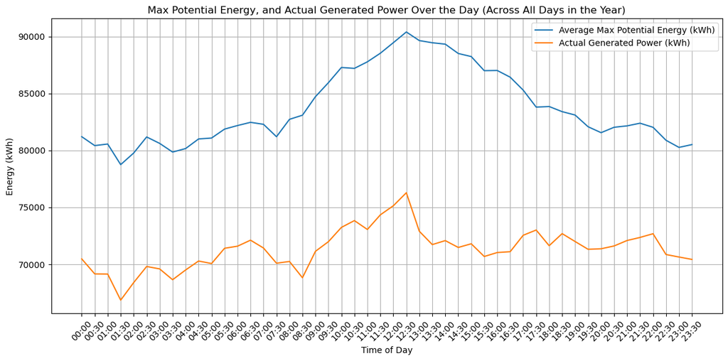

```python
plt.figure(figsize=(12, 6))

# Plot the average curtailed energy
# plt.plot(average_curtailment_by_time.index, average_curtailment_by_time, label='Average Curtailed Energy (kWh)', color='red')

# Plot the average max potential energy
plt.plot(average_max_energy_by_time.index, average_max_energy_by_time, label='Average Max Potential Energy (kWh)')

# Plot the actual generated power (difference between max potential and curtailed)
plt.plot(actual_generated_power.index, actual_generated_power, label='Actual Generated Power (kWh)')


# Adding labels and title
plt.xlabel('Time of Day')
plt.ylabel('Energy (kWh)')
plt.title('Max Potential Energy, and Actual Generated Power Over the Day (Across All Days in the Year)')

# Display legend
plt.legend()

# Rotate x-axis labels for better readability
plt.xticks(rotation=45)

# Display grid for better visibility
plt.grid(True)

# Tight layout to ensure labels and title fit
plt.tight_layout()

# Show the plot
plt.show()
```

# Appendix B - Demand

#### Demand Difference

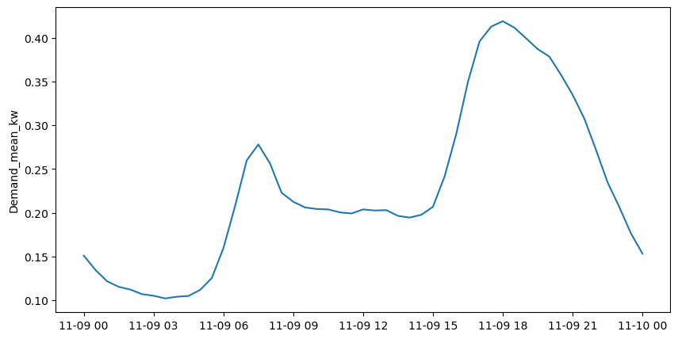

```python
day_demand1 = resident_demand[14976:15025]
plt.figure(figsize=(10,5))
plt.plot(day_demand1["Demand_mean_kw"])
plt.ylabel('Demand_mean_kw')
plt.show()
```

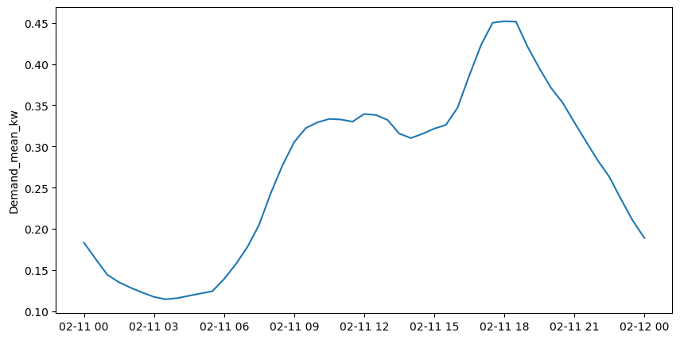

```python
day_demand2 = resident_demand[1968:2017]
plt.figure(figsize=(10,5))
plt.plot(day_demand2["Demand_mean_kw"])
plt.ylabel('Demand_mean_kw')
plt.show()
```

#### Demand vs. Curtailment Across Time

```python
# Extract the time from the 'Timestamp' and create a new column 'Time'
resident_demand['Time'] = resident_demand.index.time

# Convert the time to numeric format: minutes since midnight
resident_demand['Time_in_minutes'] = resident_demand.index.hour * 60 + resident_demand.index.minute

# Group by the numeric time and calculate the mean for each 30-minute time slot across all days
average_demand_energy_by_time = resident_demand.groupby('Time_in_minutes')['Energy_kWh'].mean()
total_demand_energy_by_time = average_demand_energy_by_time * 10385

total_demand_energy_by_time.index = [f'{h:02}:{m:02}' for h, m in zip(*divmod(total_demand_energy_by_time.index, 60))]
```

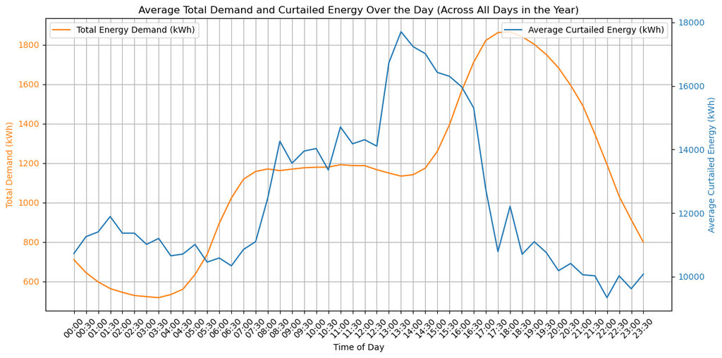

```python
# Create a plot with two y-axes
fig, ax1 = plt.subplots(figsize=(12, 6))

# Plot the total demand for all households (on the left y-axis)
ax1.plot(total_demand_energy_by_time.index, total_demand_energy_by_time, label='Total Energy Demand (kWh)', color='#ff7f0e')
ax1.set_xlabel('Time of Day')
ax1.set_ylabel('Total Demand (kWh)', color='#ff7f0e')
ax1.tick_params(axis='y', labelcolor='#ff7f0e')

# Display grid for better visibility
plt.grid(True)

plt.xticks(rotation=45)

# Create a second y-axis for average curtailed energy
ax2 = ax1.twinx()
ax2.plot(average_curtailment_by_time.index, average_curtailment_by_time, label='Average Curtailed Energy (kWh)', color='#1f77b4')
ax2.set_ylabel('Average Curtailed Energy (kWh)', color='#1f77b4')
ax2.tick_params(axis='y', labelcolor='#1f77b4')

# Adding a title
plt.title('Average Total Demand and Curtailed Energy Over the Day (Across All Days in the Year)')

# Display the legends for both axes
ax1.legend(loc='upper left')
ax2.legend(loc='upper right')

# Display grid for better visibility
# plt.grid(True)

# Tight layout to ensure labels and title fit
plt.tight_layout()

# Show the plot
plt.show()
```